# SpotifyWorkshop

Ty

2026-01-18

### TABLE OF CONTENTS:

*Graphs*

- **G1-G3 –> (Visual)**
  - Progression of ‘Drake’ listening graph
- **G4 –> (Visual)**
  - Artists that I have at least 5 songs added in liked songs (6 artists specifically selected from my overall top 25 artists streamed) frequency of streams broken up by months and smoothed.
- **G5 –> (Visual)**
  - Daily Listening Time for Top 6 Artists (All Time)

*Concepts*

- **#12 –> (Concept + List)**
  - Unlistened to Songs in Liked Songs
- **#2 –> (Visuals, Concept + Lists)**
  - How often do we search for a “sound”?
  - Time spent on Shuffle
  - Spotify streaming by device
- **#6 –> (Visuals, Concept + Lists)**
  - Clickrow Songs: What songs do I seek out?
- **#7 –> (Concept + List)**
  - First time ever playing top song of the year (in minutes)
- **#5 –> (Visuals)**
  - Typical day of listening by year
  - Intentional (clickrow) plays
    - by ARTIST
    - by SONG
  - STREAKS: Consecutive ‘n’ months an Artist spent in my Top 3 of listening minutes
- **#8 –> (Visuals, Concept + Lists)**
  - Listening Minutes per Year
  - Highest Day of Listening per Year
  - Number of Unique listens per Year
    - per Month
- **#9 –> (Concept + List)**
  - Songs seen the Most, Playlist-to-Playlist
  - Versatility of a Track
- **#10 –> (Concept + Lists)**
  - Artists often listened to TOGETHER (same two-hour block)
- **#14 –> (Concept + List)**
  - Friends-Trip Playlist
- **#15 –> (Concept + Lists)**
  - Nostalgic Listening

### Data loading and Workshop:

```r
library(jsonlite)
library(dplyr)
library(lubridate)
```

```r
files <- list.files("Ext.Stream.Hist", pattern = "\\.json$", full.names = TRUE)

data_list <- lapply(files, fromJSON)

combined_data <- do.call(rbind, data_list)

str(combined_data)
```

```
## 'data.frame':    171203 obs. of  23 variables:
##  $ ts                               : chr  "2019-01-06T23:51:35Z" "2019-01-07T00:13:14Z" "2019-01-07T00:16:40Z" "2019-01-07T01:40:20Z" ...
##  $ platform                         : chr  "iOS 12.1.2 (iPhone10,1)" "iOS 12.1.2 (iPhone10,1)" "iOS 12.1.2 (iPhone10,1)" "iOS 12.1.2 (iPhone10,1)" ...
##  $ ms_played                        : int  5290 3861 11498 99218 3622 19806 5735 1602 195637 89537 ...
##  $ conn_country                     : chr  "US" "US" "US" "US" ...
##  $ ip_addr                          : chr  "68.115.33.102" "68.115.33.102" "68.115.33.102" "174.197.9.219" ...
##  $ master_metadata_track_name       : chr  "Excuse Me" "Burn Fast" "10AM/Save The World (feat. Gucci Mane)" "10AM/Save The World (feat. Gucci Mane)" ...
##  $ master_metadata_album_artist_name: chr  "A$AP Rocky" "Bryce Fox" "Metro Boomin" "Metro Boomin" ...
##  $ master_metadata_album_album_name : chr  "AT.LONG.LAST.A$AP" "Burn Fast" "NOT ALL HEROES WEAR CAPES" "NOT ALL HEROES WEAR CAPES" ...
##  $ spotify_track_uri                : chr  "spotify:track:3I8MbKRkS2IBDuslhCS3iT" "spotify:track:4Ft7PYNG9LYzDWNeKqdkdz" "spotify:track:00KjOnN3U40e3lXFUOue7h" "spotify:track:00KjOnN3U40e3lXFUOue7h" ...
##  $ episode_name                     : chr  NA NA NA NA ...
##  $ episode_show_name                : chr  NA NA NA NA ...
##  $ spotify_episode_uri              : chr  NA NA NA NA ...
##  $ audiobook_title                  : chr  NA NA NA NA ...
##  $ audiobook_uri                    : chr  NA NA NA NA ...
##  $ audiobook_chapter_uri            : chr  NA NA NA NA ...
##  $ audiobook_chapter_title          : chr  NA NA NA NA ...
##  $ reason_start                     : chr  "clickrow" "clickrow" "clickrow" "appload" ...
##  $ reason_end                       : chr  "endplay" "logout" "logout" "endplay" ...
##  $ shuffle                          : logi  FALSE FALSE FALSE FALSE FALSE FALSE ...
##  $ skipped                          : logi  FALSE FALSE FALSE FALSE FALSE FALSE ...
##  $ offline                          : logi  FALSE FALSE FALSE FALSE FALSE FALSE ...
##  $ offline_timestamp                : num  NA NA NA NA NA NA NA NA NA NA ...
##  $ incognito_mode                   : logi  FALSE FALSE FALSE FALSE FALSE FALSE ...
```

```r
combined_data <- combined_data %>%
  mutate(ts = ymd_hms(ts))
```

```r
oct_2022 <- combined_data %>%
  filter(ts >= ymd("2019-01-01"))

top_songs_oct2022 <- oct_2022 %>%
  filter(!is.na(master_metadata_track_name)) %>%
  group_by(master_metadata_track_name, master_metadata_album_artist_name) %>%
  summarize(total_ms = sum(ms_played), .groups = "drop") %>%
  arrange(desc(total_ms)) %>%

  slice(1:27)

top_songs_oct2022
```

```
## # A tibble: 27 × 3
##    master_metadata_track_name                    master_metadata_albu…¹ total_ms
##    <chr>                                         <chr>                     <int>
##  1 Good Things Fall Apart (with Jon Bellion)     ILLENIUM               89516167
##  2 After Hours                                   The Weeknd             71287657
##  3 Heaven Knows                                  Five For Fighting      62186467
##  4 Welcome To Heartbreak                         Kanye West             59344977
##  5 everything i wanted                           Billie Eilish          55608816
##  6 10 Hour Box Fan (No Distractions)             Big Fan                54909267
##  7 Wounds                                        Quinn XCII             51042974
##  8 Call Your Mom                                 Noah Kahan             47022792
##  9 I Can't Stop Drinking About You - Chainsmoke… Bebe Rexha             42394669
## 10 Just What I Am                                Kid Cudi               40680384
## # ℹ 17 more rows
## # ℹ abbreviated name: ¹master_metadata_album_artist_name
```

```r
sec <-  89516167/1000
in_minutes <- sec/60
in_minutes
```

```
## [1] 1491.936
```

```r
names(combined_data)
```

```
##  [1] "ts"                                "platform"
##  [3] "ms_played"                         "conn_country"
##  [5] "ip_addr"                           "master_metadata_track_name"
##  [7] "master_metadata_album_artist_name" "master_metadata_album_album_name"
##  [9] "spotify_track_uri"                 "episode_name"
## [11] "episode_show_name"                 "spotify_episode_uri"
## [13] "audiobook_title"                   "audiobook_uri"
## [15] "audiobook_chapter_uri"             "audiobook_chapter_title"
## [17] "reason_start"                      "reason_end"
## [19] "shuffle"                           "skipped"
## [21] "offline"                           "offline_timestamp"
## [23] "incognito_mode"
```

```r
min(combined_data$ts, na.rm = TRUE)
```

```
## [1] "2019-01-06 23:51:35 UTC"
```

```r
as.Date(min(combined_data$ts, na.rm = TRUE))
```

```
## [1] "2019-01-06"
```

```r
account_dir <- "Account.Data"

list.files(account_dir, recursive = TRUE)
```

```
##  [1] "Follow.json"                       "Identifiers.json"
##  [3] "Identity.json"                     "Inferences.json"
##  [5] "Marquee.json"                      "MessageData.json"
##  [7] "Payments.json"                     "Playlist1.json"
##  [9] "Read_Me_First.pdf"                 "SearchQueries.json"
## [11] "StreamingHistory_audiobook_0.json" "StreamingHistory_music_0.json"
## [13] "StreamingHistory_music_1.json"     "StreamingHistory_music_2.json"
## [15] "StreamingHistory_music_3.json"     "StreamingHistory_podcast_0.json"
## [17] "UserAddress.json"                  "Userdata.json"
## [19] "UserFestivalsDataForSAR.json"      "UserPrompts.json"
## [21] "Wrapped2024.json"                  "YourLibrary.json"
## [23] "YourSoundCapsule.json"
```

```r
account_files <- list.files(
  account_dir,
  pattern = "\\.json$",
  full.names = TRUE,
  recursive = TRUE
)

account_raw <- lapply(account_files, function(f) {
  message("Reading: ", basename(f))
  tryCatch(
    fromJSON(f, flatten = TRUE),
    error = function(e) {
      message("  -> Skipping ", basename(f), " (", e$message, ")")
      NULL
    }
  )
})
```

```r
names(account_raw) <- tools::file_path_sans_ext(basename(account_files))
account_raw <- account_raw[!vapply(account_raw, is.null, logical(1))]

names(account_raw)
```

```
##  [1] "Follow"                       "Identifiers"
##  [3] "Identity"                     "Inferences"
##  [5] "Marquee"                      "MessageData"
##  [7] "Payments"                     "Playlist1"
##  [9] "SearchQueries"                "StreamingHistory_audiobook_0"
## [11] "StreamingHistory_music_0"     "StreamingHistory_music_1"
## [13] "StreamingHistory_music_2"     "StreamingHistory_music_3"
## [15] "StreamingHistory_podcast_0"   "Userdata"
## [17] "UserFestivalsDataForSAR"      "UserPrompts"
## [19] "Wrapped2024"                  "YourLibrary"
## [21] "YourSoundCapsule"
```

```r
your_library_raw <- account_raw$YourLibrary

str(your_library_raw, max.level = 2)
```

```
## List of 9
##  $ tracks       :'data.frame':   2838 obs. of  4 variables:
##   ..$ artist: chr [1:2838] "Eminem" "Wiz Khalifa" "Lil Wayne" "Lil Uzi Vert" ...
##   ..$ album : chr [1:2838] "When I'm Gone" "The Thrill (feat. Empire of the Sun)" "I Am Not A Human Being II" "Eternal Atake (Deluxe) - LUV vs. The World 2" ...
##   ..$ track : chr [1:2838] "When I'm Gone" "The Thrill" "Rich As Fuck" "I Can Show You" ...
##   ..$ uri   : chr [1:2838] "spotify:track:2lRI7n5b9jlPYsEpRuots6" "spotify:track:56oGoEjA9eTZYgsttEFKY3" "spotify:track:3Eq7yD58dIXqOgw1j7NFhY" "spotify:track:0AhJag7VI8uFf3mJFsTwvf" ...
##  $ albums       :'data.frame':   24 obs. of  3 variables:
##   ..$ artist: chr [1:24] "Kid Cudi" "Zach Bryan" "ILLENIUM" "Fireboy DML" ...
##   ..$ album : chr [1:24] "Free" "Streets of London" "All That Really Matters" "Peru (R3HAB Remix)" ...
##   ..$ uri   : chr [1:24] "spotify:album:2GD42iPt0jtcudvlMksV1d" "spotify:album:0kUGW2gfvAtD4yNmylxsLF" "spotify:album:2OW7PzcHkPrB2fY0fLvx4Q" "spotify:album:4aJ4phZnjQ1LQC8erkLOi4" ...
##  $ shows        :'data.frame':   6 obs. of  3 variables:
##   ..$ name     : chr [1:6] "Call Her Daddy" "Life is Short with Justin Long" "SmartLess" "Stuff You Should Know" ...
##   ..$ publisher: chr [1:6] "Alex Cooper" "Wondery" "Jason Bateman, Sean Hayes, Will Arnett" "iHeartPodcasts" ...
##   ..$ uri      : chr [1:6] "spotify:show:7bnjJ7Va1nM07Um4Od55dW" "spotify:show:4bqGBlGEpQFLdC7yVlIjKw" "spotify:show:0Yzd0g8NYmn27k2HFNplv7" "spotify:show:0ofXAdFIQQRsCYj9754UFx" ...
##  $ episodes     :'data.frame':   5 obs. of  3 variables:
##   ..$ name: chr [1:5] "Vol. 15" "Vol. 15" "\"Julia Louis-Dreyfus\"" "Sleep Sounds Rain & Thunderstorm White Noise 8 Hours | Fall Asleep with Rainstorm Sound Masking" ...
##   ..$ show: chr [1:5] "2F Mixes" "Two Friends BB Mixes" "SmartLess" "Relaxing White Noise" ...
##   ..$ uri : chr [1:5] "spotify:episode:3JoacgFmzKzgkBAaFWBQh2" "spotify:episode:0t1WuCGeKpZY6eMqbgF9Nb" "spotify:episode:7p7AjxcmgyjWdAKFNOjaox" "spotify:episode:5GTeZhT4T8zxxjSSSM2yne" ...
##  $ bannedTracks : list()
##  $ artists      :'data.frame':   31 obs. of  2 variables:
##   ..$ name: chr [1:31] "A$AP Rocky" "Drake" "Frank Ocean" "Grupo Supr3me" ...
##   ..$ uri : chr [1:31] "spotify:artist:13ubrt8QOOCPljQ2FL1Kca" "spotify:artist:3TVXtAsR1Inumwj472S9r4" "spotify:artist:2h93pZq0e7k5yf4dywlkpM" "spotify:artist:2D04F1wci9jME32L68xaAv" ...
##  $ bannedArtists: list()
##  $ pageMatch    : list()
##  $ other        : list()
```

```r
names(your_library_raw)
```

```
## [1] "tracks"        "albums"        "shows"         "episodes"
## [5] "bannedTracks"  "artists"       "bannedArtists" "pageMatch"
## [9] "other"
```

```r
# extract just the liked tracks table from YourLibrary
your_library_tracks <- your_library_raw$tracks

# see its structure
str(your_library_tracks, max.level = 2)
```

```
## 'data.frame':    2838 obs. of  4 variables:
##  $ artist: chr  "Eminem" "Wiz Khalifa" "Lil Wayne" "Lil Uzi Vert" ...
##  $ album : chr  "When I'm Gone" "The Thrill (feat. Empire of the Sun)" "I Am Not A Human Being II" "Eternal Atake (Deluxe) - LUV vs. The World 2" ...
##  $ track : chr  "When I'm Gone" "The Thrill" "Rich As Fuck" "I Can Show You" ...
##  $ uri   : chr  "spotify:track:2lRI7n5b9jlPYsEpRuots6" "spotify:track:56oGoEjA9eTZYgsttEFKY3" "spotify:track:3Eq7yD58dIXqOgw1j7NFhY" "spotify:track:0AhJag7VI8uFf3mJFsTwvf" ...
```

```r
names(your_library_tracks)
```

```
## [1] "artist" "album"  "track"  "uri"
```

```r
# prepare liked songs dataset for joining with streaming history
liked_songs <- your_library_tracks %>%
  rename(
    track_uri = uri,
    track_name = track,
    artist_name = artist
  )
```

```r
# make sure timestamp in streaming history is a proper datetime
combined_data <- combined_data %>%
  mutate(ts = ymd_hms(ts))
```

```r
# join streaming history with your liked songs
streams_liked <- combined_data %>%
  inner_join(liked_songs, by = c("spotify_track_uri" = "track_uri"))
```

```r
# count how many liked tracks each artist has
artists_5plus <- liked_songs %>%
  group_by(artist_name) %>%
  summarize(n_liked_tracks = n(), .groups = "drop") %>%
  filter(n_liked_tracks >= 5)

artists_5plus
```

```
## # A tibble: 117 × 2
##    artist_name   n_liked_tracks
##    <chr>                  <int>
##  1 21 Savage                  7
##  2 6LACK                     22
##  3 A$AP Rocky                 7
##  4 AJR                        5
##  5 Alan Walker                6
##  6 Avicii                     6
##  7 Benson Boone              14
##  8 Billie Eilish             21
##  9 Blackmill                  5
## 10 Bryce Vine                20
## # ℹ 107 more rows
```

```r
# keep only streams from artists with >= 5 liked songs
streams_liked_5plus <- streams_liked %>%
  semi_join(artists_5plus, by = "artist_name")
```

```r
# add a month column
streams_liked_5plus <- streams_liked_5plus %>%
  mutate(month = floor_date(ts, "month"))

# aggregate listening by month per artist
artist_month_counts <- streams_liked_5plus %>%
  group_by(artist_name, month) %>%
  summarize(
    plays = n(),                 # number of plays
    total_ms = sum(ms_played),  # total listening time
    .groups = "drop"
  )

# inspect the result
head(artist_month_counts)
```

```
## # A tibble: 6 × 4
##   artist_name month               plays total_ms
##   <chr>       <dttm>              <int>    <int>
## 1 21 Savage   2019-01-01 00:00:00    17   614805
## 2 21 Savage   2019-02-01 00:00:00    10   874421
## 3 21 Savage   2019-03-01 00:00:00     2    58537
## 4 21 Savage   2019-04-01 00:00:00     6   152825
## 5 21 Savage   2019-05-01 00:00:00     7   808105
## 6 21 Savage   2019-06-01 00:00:00     9   899358
```

```r
library(ggplot2)

# pick the artist you want to look at
artist_to_plot <- "Drake"   # <-- change this name whenever you want

artist_data <- artist_month_counts %>%
  filter(artist_name == artist_to_plot)

head(artist_data)
```

```
## # A tibble: 6 × 4
##   artist_name month               plays total_ms
##   <chr>       <dttm>              <int>    <int>
## 1 Drake       2019-01-01 00:00:00    98  9396425
## 2 Drake       2019-02-01 00:00:00   113  9013758
## 3 Drake       2019-03-01 00:00:00    79  5953256
## 4 Drake       2019-04-01 00:00:00   188 11679918
## 5 Drake       2019-05-01 00:00:00   160 10605776
## 6 Drake       2019-06-01 00:00:00   201 18150771
```

### G1-G3

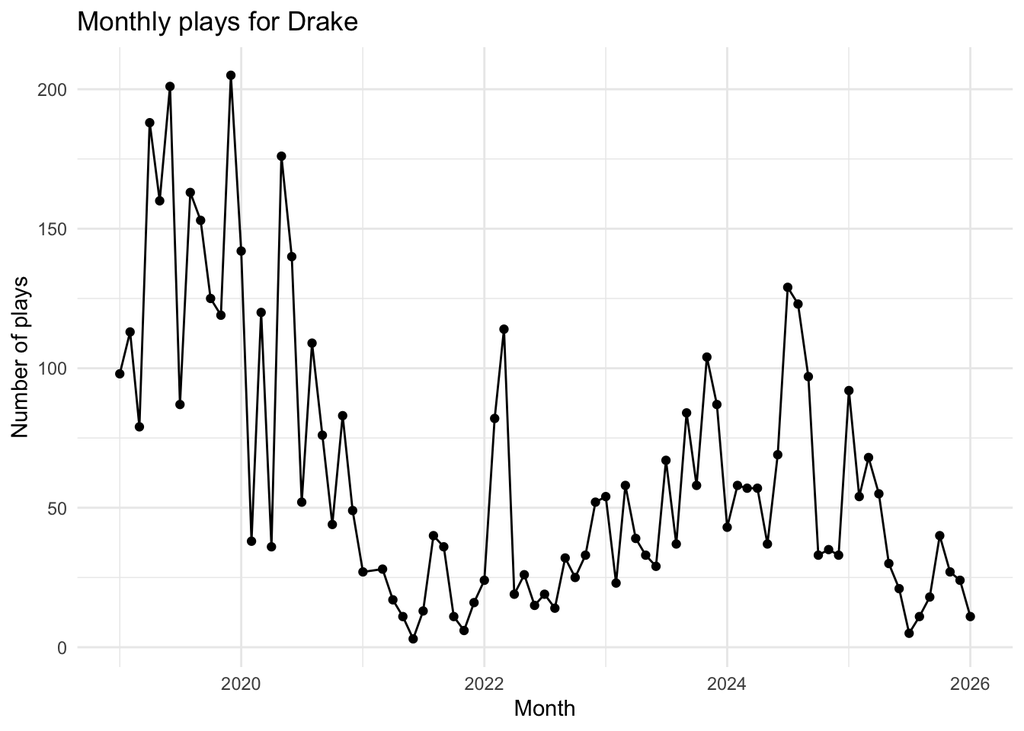

```r
ggplot(artist_data, aes(x = month, y = plays)) +
  geom_line() +
  geom_point() +
  labs(
    title = paste("Monthly plays for", artist_to_plot),
    x = "Month",
    y = "Number of plays"
  ) +
  theme_minimal()
```

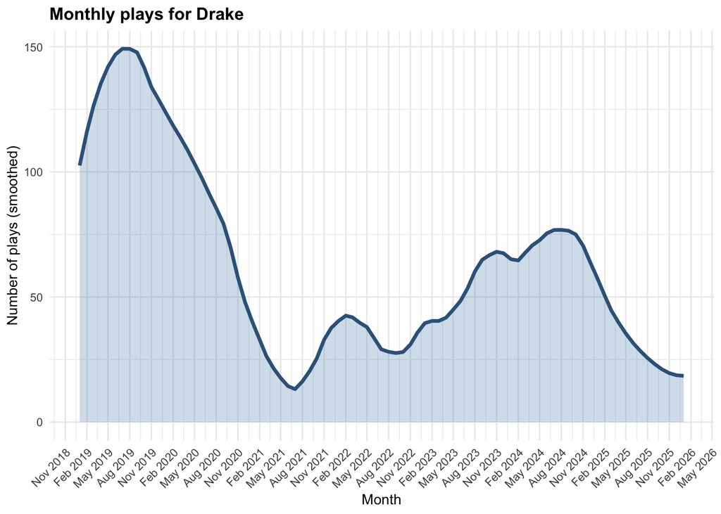

````r
# make the figure bigger in the Rmd header for this chunk:
# ```{r, fig.width=12, fig.height=6}

artist_to_plot <- "Drake"

# data for that artist
artist_data <- artist_month_counts %>%
  filter(artist_name == artist_to_plot) %>%
  arrange(month)

# smooth the plays with a loess curve
fit <- loess(plays ~ as.numeric(month), data = artist_data, span = 0.25)
artist_data$plays_smooth <- predict(fit)

ggplot(artist_data, aes(x = month, y = plays_smooth)) +
  # shaded area under the curve
  geom_ribbon(aes(ymin = 0, ymax = plays_smooth),
              fill = "steelblue", alpha = 0.25) +
  # bold smoothed line
  geom_line(color = "steelblue4", size = 1.2) +
  labs(
    title = paste("Monthly plays for", artist_to_plot),
    x = "Month",
    y = "Number of plays (smoothed)"
  ) +
  # nicer, less-overlapping date labels
  scale_x_datetime(
    date_breaks = "3 months",        # try "6 months" if still crowded
    date_labels = "%b %Y"
  ) +
  theme_minimal(base_size = 10) +
  theme(
    axis.text.x = element_text(angle = 45, hjust = 1),
    plot.title = element_text(face = "bold")
  )
````

```r
artist_month_counts_all <- combined_data %>%
  mutate(
    ts   = ymd_hms(ts, tz = "UTC"),
    month = floor_date(ts, "month"),
    artist_name = master_metadata_album_artist_name
  ) %>%
  group_by(artist_name, month) %>%
  summarize(
    plays    = n(),
    total_ms = sum(ms_played),
    .groups = "drop"
  )
```

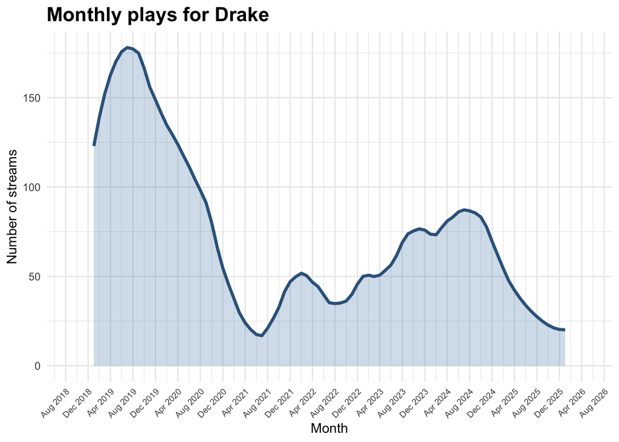

```r
artist_to_plot <- "Drake"   # can be any artist name you want

# use the ALL-streams monthly data instead of liked-only
artist_data_all <- artist_month_counts_all %>%
  filter(artist_name == artist_to_plot) %>%
  arrange(month)

# smooth the plays (same as before)
fit <- loess(plays ~ as.numeric(month), data = artist_data_all, span = 0.25)
artist_data_all$plays_smooth <- predict(fit)

ggplot(artist_data_all, aes(x = month, y = plays_smooth)) +
  geom_ribbon(aes(ymin = 0, ymax = plays_smooth),
              fill = "steelblue", alpha = 0.25) +
  geom_line(color = "steelblue4", size = 1.2) +
  labs(
    title = paste("Monthly plays for", artist_to_plot),
    x = "Month",
    y = "Number of streams"
  ) +
  scale_x_datetime(
    date_breaks = "4 months",
    date_labels = "%b %Y",
    expand = expansion(mult = c(0.1, 0.1))  # keep the stretched look
  ) +
  theme_minimal(base_size = 11) +
  theme(
    axis.text.x  = element_text(angle = 45, hjust = 1, size = 7),
    plot.title   = element_text(face = "bold", size = 16)
  )
```

checking boundaries:

```r
max(combined_data$ts, na.rm = TRUE)
```

```
## [1] "2026-01-13 23:59:24 UTC"
```

```r
min(combined_data$ts, na.rm = TRUE)
```

```
## [1] "2019-01-06 23:51:35 UTC"
```

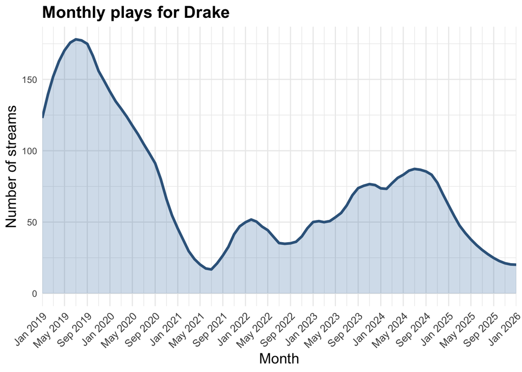

```r
#same as above plus format changes

artist_to_plot <- "Drake"  # change this to any artist name you want

# use the ALL-streams monthly data instead of liked-only
artist_data_all <- artist_month_counts_all %>%
  filter(artist_name == artist_to_plot) %>%
  arrange(month)

# smooth the plays (same as before)
fit <- loess(plays ~ as.numeric(month), data = artist_data_all, span = 0.25)
artist_data_all$plays_smooth <- predict(fit)

ggplot(artist_data_all, aes(x = month, y = plays_smooth)) +
  geom_ribbon(aes(ymin = 0, ymax = plays_smooth),
              fill = "steelblue", alpha = 0.25) +
  geom_line(color = "steelblue4", size = 1.2) +
  labs(
    title = paste("Monthly plays for", artist_to_plot),
    x = "Month",
    y = "Number of streams"
  ) +
  scale_x_datetime(
    limits = range(artist_data_all$month, na.rm = TRUE),  #cut off exactly at min/max
    date_breaks = "4 months",
    date_labels = "%b %Y",
    expand = c(0, 0)                                     # no extra empty months on ends
  ) +
  theme_minimal(base_size = 11) +
  theme(
    axis.text.x  = element_text(angle = 45, hjust = 1, size = 10),  #bigger month labels
    axis.title.x = element_text(size = 14),                         #bigger axis titles
    axis.title.y = element_text(size = 14),
    plot.title   = element_text(face = "bold", size = 16)
  )
```

```r
artist_totals <- artist_month_counts_all %>%
  group_by(artist_name) %>%
  summarize(total_streams = sum(plays), .groups = "drop") %>%
  arrange(desc(total_streams))

head(artist_totals, 25)
```

```
## # A tibble: 25 × 2
##    artist_name      total_streams
##    <chr>                    <int>
##  1 Drake                     6185
##  2 Kid Cudi                  6134
##  3 Lil Uzi Vert              4193
##  4 Quinn XCII                3764
##  5 Travis Scott              3057
##  6 The Chainsmokers          2795
##  7 The Weeknd                2472
##  8 Kanye West                2410
##  9 Juice WRLD                2333
## 10 Wiz Khalifa               2155
## # ℹ 15 more rows
```

### G4

```r
library(purrr)
```

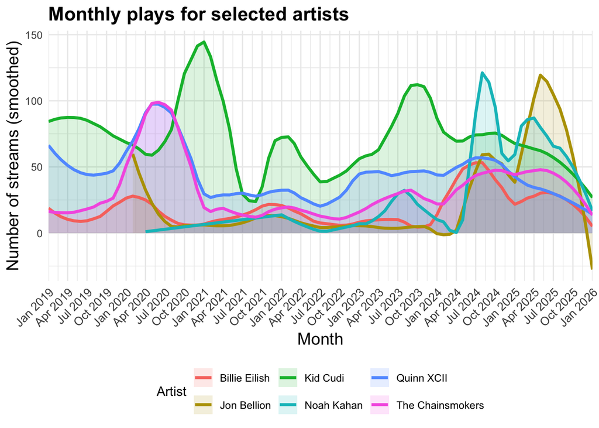

```r
# 6 artists you chose
artists_selected <- c(
  "Kid Cudi",
  "The Chainsmokers",
  "Quinn XCII",
  "Billie Eilish",
  "Jon Bellion",
  "Noah Kahan"
)

# build a smoothed monthly dataset for just these artists
multi_artist_data <- map_dfr(artists_selected, function(a) {
  df <- artist_month_counts_all %>%
    filter(artist_name == a) %>%
    arrange(month)

  # skip if no data for that name (just in case)
  if (nrow(df) == 0) return(NULL)

  fit <- loess(plays ~ as.numeric(month), data = df, span = 0.25)
  df$plays_smooth <- predict(fit)
  df
})

# make sure we actually got data
stopifnot(nrow(multi_artist_data) > 0)

ggplot(multi_artist_data,
       aes(x = month, y = plays_smooth,
           color = artist_name, fill = artist_name)) +
  # shaded area under each artist's curve
  geom_ribbon(aes(ymin = 0, ymax = plays_smooth),
              alpha = 0.15, color = NA) +
  # bold smoothed line
  geom_line(size = 1.2) +
  labs(
    title = "Monthly plays for selected artists",
    x = "Month",
    y = "Number of streams (smoothed)",
    color = "Artist",
    fill  = "Artist"
  ) +
  scale_x_datetime(
    limits = range(multi_artist_data$month, na.rm = TRUE),  # cut exactly at min/max
    date_breaks = "3 months",
    date_labels = "%b %Y",
    expand = c(0, 0)
  ) +
  theme_minimal(base_size = 11) +
  theme(
    axis.text.x  = element_text(angle = 45, hjust = 1, size = 10),
    axis.title.x = element_text(size = 14),
    axis.title.y = element_text(size = 14),
    plot.title   = element_text(face = "bold", size = 16),
    legend.position = "bottom"
  )
```

This classified as: Artists that I have at least 5 songs added in liked songs (6 artists specifically selected from my overall top 25 artists streamed) frequency of streams broken up by months and smoothed.

```r
names(account_raw)[grepl("Playlist", names(account_raw))]
```

```
## [1] "Playlist1"
```

```r
str(account_raw$Playlist1, max.level = 2)
```

```
## List of 1
##  $ playlists:'data.frame':   21 obs. of  6 variables:
##   ..$ name             : chr [1:21] "headphones" "My playlist #22" "likedsongs " "Unique Vibes: It Is What It Is" ...
##   ..$ lastModifiedDate : chr [1:21] "2025-12-23" "2025-11-14" "2025-04-08" "2024-11-25" ...
##   ..$ collaborators    :List of 21
##   ..$ items            :List of 21
##   ..$ description      : chr [1:21] NA NA NA "Curated with AI." ...
##   ..$ numberOfFollowers: int [1:21] 0 0 0 0 0 0 0 2 0 0 ...
```

```r
# list all playlist names
account_raw$Playlist1$playlists$name
```

```
##  [1] "headphones"                     "My playlist #22"
##  [3] "likedsongs "                    "Unique Vibes: It Is What It Is"
##  [5] "Breath Vibes"                   "Tb"
##  [7] "gym ‘24"                        "Miami🦓"
##  [9] "new workout"                    "moving on"
## [11] "🤫"                             "u know"
## [13] "feel better"                    "miss u"
## [15] "home"                           "Sanguine Paradise"
## [17] "Makae"                          "game time"
## [19] "low key"                        "Liked from Radio"
## [21] "Bus"
```

So I have 21 playlists with 6 variables for each.

### G5

```r
# get top 6 artists ever (by total streams)
top_artists <- combined_data %>%
  filter(!is.na(master_metadata_album_artist_name)) %>%
  count(master_metadata_album_artist_name, sort = TRUE) %>%
  slice_head(n = 6) %>%
  pull(master_metadata_album_artist_name)

top_artists
```

```
## [1] "Drake"            "Kid Cudi"         "Lil Uzi Vert"     "Quinn XCII"
## [5] "Travis Scott"     "The Chainsmokers"
```

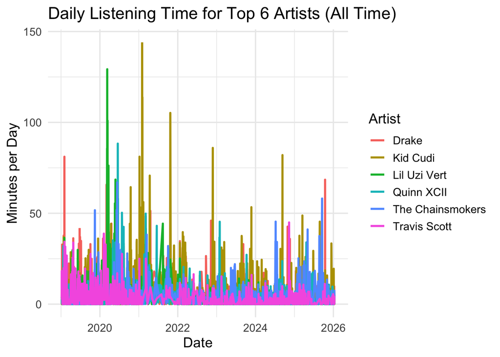

```r
# filter streaming data to only those artists-- go by day
df6 <- combined_data %>%
  filter(master_metadata_album_artist_name %in% top_artists) %>%
  mutate(
    date   = as_date(ts),
    artist = master_metadata_album_artist_name
  ) %>%
  group_by(date, artist) %>%
  summarise(
    minutes = sum(ms_played) / 60000,   # convert ms to minutes
    .groups = "drop"
  )

# plot – same style as before
ggplot(df6, aes(x = date, y = minutes, color = artist)) +
  geom_line(size = 1) +
  labs(
    title  = "Daily Listening Time for Top 6 Artists (All Time)",
    x      = "Date",
    y      = "Minutes per Day",
    color  = "Artist"
  ) +
  theme_minimal(base_size = 14)
```

### #12

CLEAN SLATE- songs to get rid of = songs played 5 times or less (would be cool to add (within 6 months of having it in liked songs))

*will give you a screen that has a checkmark in the top right corner (and a X in the top left corner) to confirm before deleting those songs. You CAN scroll through all of the songs to see if you are ok with deleting that cluster/rundown of songs. Deleted on accident can be recovered.

This shows all the songs in my ‘liked songs’ that i have only played 5 times or less. 5 is just my own opinion of how many times should qualify as being not enough plays to keep in ‘liked songs’. This is a good chunk of songs that would free up some download space.

```r
likedsongs_amtplayed <- combined_data %>%
  semi_join(liked_songs, by = c("spotify_track_uri" = "track_uri")) %>%
  group_by(
    spotify_track_uri,
    master_metadata_track_name,
    master_metadata_album_artist_name
  ) %>%
  summarise(
    total_plays = n(),
    total_minutes = sum(ms_played, na.rm = TRUE) / 60000,
    .groups = "drop"
  )

liked_songs_5_or_less <- likedsongs_amtplayed %>%
  filter(total_plays <= 5) %>%
  arrange(total_plays, total_minutes)


liked_songs_5_or_less
```

```
## # A tibble: 144 × 5
##    spotify_track_uri   master_metadata_trac…¹ master_metadata_albu…² total_plays
##    <chr>               <chr>                  <chr>                        <int>
##  1 spotify:track:20dP… pick up the phone (fe… Young Thug                       1
##  2 spotify:track:0g6m… Remember You           Wiz Khalifa                      1
##  3 spotify:track:5Pdq… Neverland              Kid Cudi                         1
##  4 spotify:track:4JAh… Forget Me              Lewis Capaldi                    1
##  5 spotify:track:3lUW… Pointless              Lewis Capaldi                    1
##  6 spotify:track:4gJg… 23 Island              JayDaYoungan                     1
##  7 spotify:track:05jU… Addicted               Zerb                             1
##  8 spotify:track:2Q2B… Theatrical State of M… Papooz                           1
##  9 spotify:track:1TlT… For Tonight            Giveon                           1
## 10 spotify:track:2kpz… Coming Over - filous … James Hersey                     1
## # ℹ 134 more rows
## # ℹ abbreviated names: ¹master_metadata_track_name,
## #   ²master_metadata_album_artist_name
## # ℹ 1 more variable: total_minutes <dbl>
```

Keeps all tracks in ‘liked songs’ for at least 6 months (180 days). Meaning ive had them for 6 months and i still have only listened to them under 5 times. This eliminates the “what if I just haven’t given the song long enough to know if i like it or not” type feeling.

```r
#finds earliest listening date for every song in my history and converts
first_play_dates <- combined_data %>%
  group_by(spotify_track_uri) %>%
  summarise(
    first_play_date = as.Date(min(ts)),
    .groups = "drop"
  )

liked_songs_5orless_6mo <- liked_songs_5_or_less %>%
  left_join(first_play_dates, by = "spotify_track_uri") %>%
  filter(first_play_date <= Sys.Date() - 180)

liked_songs_5orless_6mo
```

```
## # A tibble: 82 × 6
##    spotify_track_uri   master_metadata_trac…¹ master_metadata_albu…² total_plays
##    <chr>               <chr>                  <chr>                        <int>
##  1 spotify:track:20dP… pick up the phone (fe… Young Thug                       1
##  2 spotify:track:0g6m… Remember You           Wiz Khalifa                      1
##  3 spotify:track:4JAh… Forget Me              Lewis Capaldi                    1
##  4 spotify:track:3lUW… Pointless              Lewis Capaldi                    1
##  5 spotify:track:4gJg… 23 Island              JayDaYoungan                     1
##  6 spotify:track:05jU… Addicted               Zerb                             1
##  7 spotify:track:2Q2B… Theatrical State of M… Papooz                           1
##  8 spotify:track:1TlT… For Tonight            Giveon                           1
##  9 spotify:track:2kpz… Coming Over - filous … James Hersey                     1
## 10 spotify:track:29rQ… Tell Me If It Hurts    Back Talk                        1
## # ℹ 72 more rows
## # ℹ abbreviated names: ¹master_metadata_track_name,
## #   ²master_metadata_album_artist_name
## # ℹ 2 more variables: total_minutes <dbl>, first_play_date <date>
```

We had to use first time ever played instead of date liked because spotify does not release that information.

### #2

Take 2025 for example:

```r
search_q <- account_raw$SearchQueries %>%
  mutate(
    searchTime = gsub("\\[UTC\\]$", "", searchTime),
    search_dt  = ymd_hms(gsub("Z$", "", searchTime), tz = "UTC"),
    n_words    = lengths(strsplit(trimws(gsub("\\s+", " ", searchQuery)), "\\s+"))
  ) %>%
  filter(!is.na(search_dt),year(search_dt) == 2025, n_words >= 3) %>%
  arrange(search_dt) %>%
  mutate(
    gap_sec   = as.numeric(difftime(search_dt, lag(search_dt), units = "secs")),
    sessionID = cumsum(ifelse(is.na(gap_sec) | gap_sec > 30, 1, 0))
  ) %>%
  group_by(sessionID) %>%
  slice_max(nchar(searchQuery), n = 1, with_ties = FALSE) %>%
  ungroup()

lyric_search_month <- search_q %>%
  mutate(month = floor_date(search_dt, "month")) %>%
  count(month, name = "n_lyric_searches")

lyric_search_year <- search_q %>%
  mutate(year = year(search_dt)) %>%
  count(year, name = "n_lyric_searches")

lyric_search_month
```

```
## # A tibble: 3 × 2
##   month               n_lyric_searches
##   <dttm>                         <int>
## 1 2025-10-01 00:00:00                2
## 2 2025-11-01 00:00:00                6
## 3 2025-12-01 00:00:00                5
```

```r
lyric_search_year
```

```
## # A tibble: 1 × 2
##    year n_lyric_searches
##   <dbl>            <int>
## 1  2025               13
```

I classified “searching with 3 or more words” as an indication that I was trying to find a song by searching lyrics. If you agree to that connection then this is saying I searched for a song that I didn’t know the name of by searching the lyrics I remembered– 13 times last year. Not an astounding number but I am willing to bet that it happens way more across all users than me- however this is the only data I have to work with.

My point is that it happens, people search for songs in the search bar by typing in the lyrics that they remember hoping that the first song that pops up is the one in their head.

```r
library(tidyr)
library(ggplot2)

# music only (exclude podcasts / other audio): require a track uri + track metadata
music_data <- combined_data %>%
  filter(!is.na(spotify_track_uri),
         !is.na(master_metadata_track_name))

# minutes on shuffle per year (music only)
shuffle_time_year_music <- music_data %>%
  filter(shuffle == TRUE) %>%
  mutate(year = year(ts)) %>%
  summarise(minutes_shuffle = sum(ms_played, na.rm = TRUE) / 60000, .by = year) %>%
  arrange(year)

shuffle_time_year_music
```

```
##   year minutes_shuffle
## 1 2019    23706.234750
## 2 2020    23115.390867
## 3 2021     5768.392083
## 4 2022    25488.572767
## 5 2023    26770.503767
## 6 2024    33325.288783
## 7 2025    34768.613667
## 8 2026      864.510950
## 9   NA        2.619433
```

Here we have time spent on shuffle:

```r
# percent of listening time spent on shuffle per year (music only)
shuffle_percent_year_music <- music_data %>%
  mutate(year = year(ts),
         shuffle_status = ifelse(shuffle == TRUE, "shuffle", "nonshuffle")) %>%
  summarise(minutes = sum(ms_played, na.rm = TRUE) / 60000, .by = c(year, shuffle_status)) %>%
  group_by(year) %>%
  mutate(
    total_minutes = sum(minutes),
    pct = minutes / total_minutes
  ) %>%
  ungroup()

# table: shuffle minutes + percent (music only)
shuffle_summary_year_music <- shuffle_percent_year_music %>%
  filter(shuffle_status == "shuffle") %>%
  select(year, minutes_shuffle = minutes, total_minutes, pct_shuffle = pct) %>%
  arrange(year)

shuffle_time_year_music
```

```
##   year minutes_shuffle
## 1 2019    23706.234750
## 2 2020    23115.390867
## 3 2021     5768.392083
## 4 2022    25488.572767
## 5 2023    26770.503767
## 6 2024    33325.288783
## 7 2025    34768.613667
## 8 2026      864.510950
## 9   NA        2.619433
```

```r
shuffle_summary_year_music
```

```
## # A tibble: 9 × 4
##    year minutes_shuffle total_minutes pct_shuffle
##   <dbl>           <dbl>         <dbl>       <dbl>
## 1  2019        23706.        30435.         0.779
## 2  2020        23115.        49631.         0.466
## 3  2021         5768.        33782.         0.171
## 4  2022        25489.        32238.         0.791
## 5  2023        26771.        30369.         0.882
## 6  2024        33325.        37760.         0.883
## 7  2025        34769.        55016.         0.632
## 8  2026          865.         1460.         0.592
## 9    NA            2.62          2.64       0.992
```

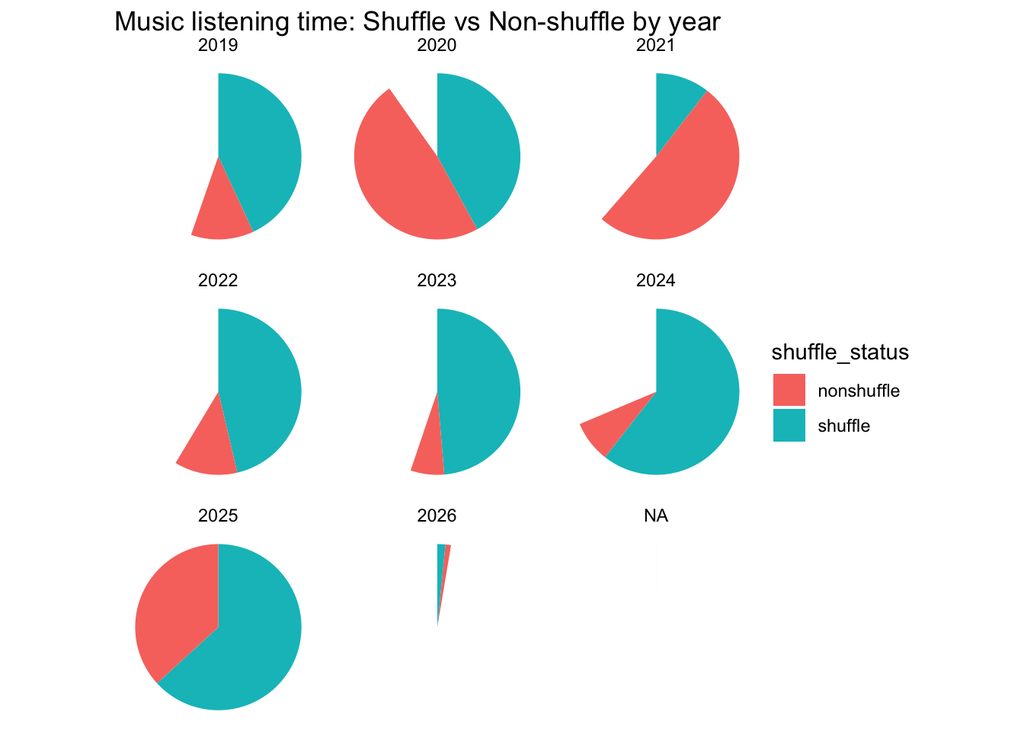

```r
# pie chart: shuffle vs nonshuffle per year (music only)
ggplot(shuffle_percent_year_music, aes(x = "", y = minutes, fill = shuffle_status)) +
  geom_col(width = 1) +
  coord_polar(theta = "y") +
  facet_wrap(~ year) +
  labs(title = "Music listening time: Shuffle vs Non-shuffle by year", x = NULL, y = NULL) +
  theme_void()
```

I am taking time spent on shuffle to also highlight how often want a certain “vibe” or type of music but do not have a specific artist in mind.

This is a huge reason that Spotify’s tailored playlists are so popular!

Shows how often we are searching for a sound rather than a specific person/group.

Here is also streamed from different devices :

```r
#not important-- just seeing what kind of <chr> names there are and how many
music_data %>%
  count(platform, sort = TRUE) %>%
  head(5)
```

```
##                  platform     n
## 1                     ios 89293
## 2 iOS 13.3.1 (iPhone12,3) 11605
## 3   iOS 14.2 (iPhone12,3)  5836
## 4 iOS 13.5.1 (iPhone12,3)  5359
## 5 iOS 15.3.1 (iPhone14,2)  5271
```

Would be much more informative with all listeners user data/ more peoples data but you can also break down how many different devices are streamed from in order to maybe cater certain things to devices.

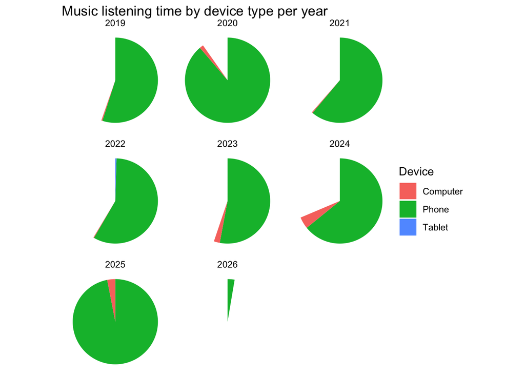

```r
library(dplyr)
library(lubridate)

music_data <- combined_data %>%
  filter(!is.na(spotify_track_uri),
         !is.na(master_metadata_track_name))

device_time_year <- music_data %>%
  mutate(
    year = year(ts),
    device_type = case_when(
      grepl("ipad", platform, ignore.case = TRUE) ~ "Tablet",
      grepl("iphone|ios|apple", platform, ignore.case = TRUE) ~ "Phone",
      TRUE ~ "Computer"
    )
  ) %>%
  filter(!is.na(year)) %>%
  summarise(
    minutes = sum(ms_played, na.rm = TRUE) / 60000,
    .by = c(year, device_type)
  ) %>%
  arrange(year, desc(minutes))

ggplot(device_time_year, aes(x = "", y = minutes, fill = device_type)) +
  geom_col(width = 1) +
  coord_polar(theta = "y") +
  facet_wrap(~ year) +
  labs(
    title = "Music listening time by device type per year",
    x = NULL, y = NULL, fill = "Device"
  ) +
  theme_void()
```

### #6

```r
combined_data %>% count(reason_start, sort = TRUE)
```

```
##    reason_start     n
## 1        fwdbtn 77969
## 2     trackdone 55607
## 3      clickrow 23147
## 4       backbtn  9351
## 5       playbtn  2155
## 6       appload  1798
## 7        remote   616
## 8       unknown   397
## 9    trackerror   158
## 10    reconnect     5
```

song specifically selected more than 10 times

```r
clickrow_songs_10plus <- combined_data %>%
  filter(reason_start == "clickrow") %>%
  group_by(
    spotify_track_uri,
    master_metadata_track_name,
    master_metadata_album_artist_name
  ) %>%
  summarise(
    n_clickrow = n(),
    .groups = "drop"
  ) %>%
  filter(n_clickrow >= 10) %>%
  arrange(desc(n_clickrow))

clickrow_songs_10plus
```

```
## # A tibble: 608 × 4
##    spotify_track_uri    master_metadata_trac…¹ master_metadata_albu…² n_clickrow
##    <chr>                <chr>                  <chr>                       <int>
##  1 <NA>                 <NA>                   <NA>                          291
##  2 spotify:track:5Wr4u… Wounds                 Quinn XCII                     97
##  3 spotify:track:3XiNC… Sanguine Paradise      Lil Uzi Vert                   82
##  4 spotify:track:0qJGl… Heaven Knows           Five For Fighting              81
##  5 spotify:track:6pooR… Good Things Fall Apar… ILLENIUM                       69
##  6 spotify:track:3yn01… Call Your Mom          Noah Kahan                     65
##  7 spotify:track:3F18I… Welcome To Heartbreak  Kanye West                     63
##  8 spotify:track:25Q6X… Big Love (with EARTHG… Louis The Child                62
##  9 spotify:track:2Fjz5… Sing Me to Sleep       Alan Walker                    61
## 10 spotify:track:6pTDP… Maybe IDK              Jon Bellion                    61
## # ℹ 598 more rows
## # ℹ abbreviated names: ¹master_metadata_track_name,
## #   ²master_metadata_album_artist_name
```

```r
library(dplyr)
library(ggplot2)
library(lubridate)

# songs intentionally selected (clickrow) 10 or more times — track-only

clickrow_songs_10plus <- combined_data %>%
  filter(
    reason_start == "clickrow",
    !is.na(spotify_track_uri)
  ) %>%
  group_by(
    spotify_track_uri,
    master_metadata_track_name,
    master_metadata_album_artist_name
  ) %>%
  summarise(
    n_clickrow = n(),
    .groups = "drop"
  ) %>%
  filter(n_clickrow >= 10) %>%
  arrange(desc(n_clickrow))

clickrow_songs_10plus
```

```
## # A tibble: 607 × 4
##    spotify_track_uri    master_metadata_trac…¹ master_metadata_albu…² n_clickrow
##    <chr>                <chr>                  <chr>                       <int>
##  1 spotify:track:5Wr4u… Wounds                 Quinn XCII                     97
##  2 spotify:track:3XiNC… Sanguine Paradise      Lil Uzi Vert                   82
##  3 spotify:track:0qJGl… Heaven Knows           Five For Fighting              81
##  4 spotify:track:6pooR… Good Things Fall Apar… ILLENIUM                       69
##  5 spotify:track:3yn01… Call Your Mom          Noah Kahan                     65
##  6 spotify:track:3F18I… Welcome To Heartbreak  Kanye West                     63
##  7 spotify:track:25Q6X… Big Love (with EARTHG… Louis The Child                62
##  8 spotify:track:2Fjz5… Sing Me to Sleep       Alan Walker                    61
##  9 spotify:track:6pTDP… Maybe IDK              Jon Bellion                    61
## 10 spotify:track:3ZCTV… everything i wanted    Billie Eilish                  60
## # ℹ 597 more rows
## # ℹ abbreviated names: ¹master_metadata_track_name,
## #   ²master_metadata_album_artist_name
```

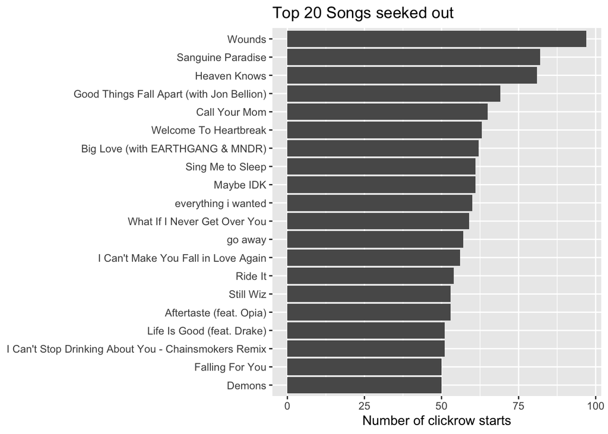

```r
# top 20 clickrow songs bar chart

clickrow_top20 <- clickrow_songs_10plus %>%
  slice_max(n_clickrow, n = 20)

ggplot(
  clickrow_top20,
  aes(
    x = reorder(master_metadata_track_name, n_clickrow),
    y = n_clickrow
  )
) +
  geom_col() +
  coord_flip() +
  labs(
    title = "Top 20 Songs seeked out",
    x = NULL,
    y = "Number of clickrow starts"
  )
```

```r
# song-level minutes per year (music tracks only)

song_minutes_year <- combined_data %>%
  filter(
    !is.na(spotify_track_uri),
    !is.na(master_metadata_track_name)
  ) %>%
  mutate(year = year(ts)) %>%
  group_by(
    year,
    spotify_track_uri,
    master_metadata_track_name,
    master_metadata_album_artist_name
  ) %>%
  summarise(
    total_minutes = sum(ms_played, na.rm = TRUE) / 60000,
    clickrow_minutes = sum(ms_played[reason_start == "clickrow"], na.rm = TRUE) / 60000,
    .groups = "drop"
  )

# top 20 per year by intentional (clickrow) listening time
top20_clickrow_minutes_year <- song_minutes_year %>%
  group_by(year) %>%
  arrange(desc(clickrow_minutes), .by_group = TRUE) %>%
  slice_head(n = 20) %>%
  ungroup()

# top 20 per year by total listening time
top20_total_minutes_year <- song_minutes_year %>%
  group_by(year) %>%
  arrange(desc(total_minutes), .by_group = TRUE) %>%
  slice_head(n = 20) %>%
  ungroup()

top20_clickrow_minutes_year
```

```
## # A tibble: 167 × 6
##     year spotify_track_uri         master_metadata_trac…¹ master_metadata_albu…²
##    <dbl> <chr>                     <chr>                  <chr>
##  1  2019 spotify:track:3XiNC94b4T… Sanguine Paradise      Lil Uzi Vert
##  2  2019 spotify:track:3F18I7LhWK… Welcome To Heartbreak  Kanye West
##  3  2019 spotify:track:2aGc7dZv5U… Nowhere Man            Bryce Vine
##  4  2019 spotify:track:0prF3F4FoK… When I'm Gone          Wiz Khalifa
##  5  2019 spotify:track:5mv1po6d9k… Balmain Jeans          Kid Cudi
##  6  2019 spotify:track:21GwiS6kow… Alone (feat. BJRNCK)   HappyBirthdayCalvin
##  7  2019 spotify:track:44CZRkOxv7… Doses & Mimosas        Cherub
##  8  2019 spotify:track:3sTN90bIP2… Love$ick (feat. A$AP … Mura Masa
##  9  2019 spotify:track:4dTaAiV9xF… Memories (feat. Kid C… David Guetta
## 10  2019 spotify:track:7ikHJI8Kd1… New Wave               Quinn XCII
## # ℹ 157 more rows
## # ℹ abbreviated names: ¹master_metadata_track_name,
## #   ²master_metadata_album_artist_name
## # ℹ 2 more variables: total_minutes <dbl>, clickrow_minutes <dbl>
```

```r
top20_total_minutes_year
```

```
## # A tibble: 167 × 6
##     year spotify_track_uri         master_metadata_trac…¹ master_metadata_albu…²
##    <dbl> <chr>                     <chr>                  <chr>
##  1  2019 spotify:track:3XiNC94b4T… Sanguine Paradise      Lil Uzi Vert
##  2  2019 spotify:track:3F18I7LhWK… Welcome To Heartbreak  Kanye West
##  3  2019 spotify:track:5mv1po6d9k… Balmain Jeans          Kid Cudi
##  4  2019 spotify:track:3sTN90bIP2… Love$ick (feat. A$AP … Mura Masa
##  5  2019 spotify:track:4dTaAiV9xF… Memories (feat. Kid C… David Guetta
##  6  2019 spotify:track:0odHj0qIf8… So High (feat. Ghost … Wiz Khalifa
##  7  2019 spotify:track:2kzRSiyign… No Sleep               Wiz Khalifa
##  8  2019 spotify:track:5oeKHrUHPT… She Gon Wink           Takeoff
##  9  2019 spotify:track:6MjNilJCVK… Fast                   Juice WRLD
## 10  2019 spotify:track:0AluA5RNsa… 10 Freaky Girls (with… Metro Boomin
## # ℹ 157 more rows
## # ℹ abbreviated names: ¹master_metadata_track_name,
## #   ²master_metadata_album_artist_name
## # ℹ 2 more variables: total_minutes <dbl>, clickrow_minutes <dbl>
```

```r
library(dplyr)
library(ggplot2)

# build top 10 lists per year for total minutes and clickrow minutes
top10_both_year <- bind_rows(
  song_minutes_year %>%
    group_by(year) %>%
    arrange(desc(total_minutes), .by_group = TRUE) %>%
    slice_head(n = 10) %>%
    mutate(metric = "Total minutes", metric_minutes = total_minutes) %>%
    ungroup(),

  song_minutes_year %>%
    group_by(year) %>%
    arrange(desc(clickrow_minutes), .by_group = TRUE) %>%
    slice_head(n = 10) %>%
    mutate(metric = "Clickrow minutes", metric_minutes = clickrow_minutes) %>%
    ungroup()
) %>%
  group_by(year, metric) %>%
  mutate(rank = row_number()) %>%
  ungroup() %>%
  mutate(
    song_label = paste0(master_metadata_track_name, " — ", master_metadata_album_artist_name)
  )

top10_both_year
```

```
## # A tibble: 174 × 10
##     year spotify_track_uri         master_metadata_trac…¹ master_metadata_albu…²
##    <dbl> <chr>                     <chr>                  <chr>
##  1  2019 spotify:track:3XiNC94b4T… Sanguine Paradise      Lil Uzi Vert
##  2  2019 spotify:track:3F18I7LhWK… Welcome To Heartbreak  Kanye West
##  3  2019 spotify:track:5mv1po6d9k… Balmain Jeans          Kid Cudi
##  4  2019 spotify:track:3sTN90bIP2… Love$ick (feat. A$AP … Mura Masa
##  5  2019 spotify:track:4dTaAiV9xF… Memories (feat. Kid C… David Guetta
##  6  2019 spotify:track:0odHj0qIf8… So High (feat. Ghost … Wiz Khalifa
##  7  2019 spotify:track:2kzRSiyign… No Sleep               Wiz Khalifa
##  8  2019 spotify:track:5oeKHrUHPT… She Gon Wink           Takeoff
##  9  2019 spotify:track:6MjNilJCVK… Fast                   Juice WRLD
## 10  2019 spotify:track:0AluA5RNsa… 10 Freaky Girls (with… Metro Boomin
## # ℹ 164 more rows
## # ℹ abbreviated names: ¹master_metadata_track_name,
## #   ²master_metadata_album_artist_name
## # ℹ 6 more variables: total_minutes <dbl>, clickrow_minutes <dbl>,
## #   metric <chr>, metric_minutes <dbl>, rank <int>, song_label <chr>
```

**2019**

```r
library(dplyr)

# 2019: top 10 by total minutes
top10_total_2019 <- song_minutes_year %>%
  filter(year == 2019) %>%
  arrange(desc(total_minutes)) %>%
  slice_head(n = 10) %>%
  mutate(rank = row_number()) %>%
  transmute(
    rank,
    total_song = master_metadata_track_name,
    total_artist = master_metadata_album_artist_name,
    total_minutes
  )

# 2019: top 10 by clickrow minutes
top10_clickrow_2019 <- song_minutes_year %>%
  filter(year == 2019) %>%
  arrange(desc(clickrow_minutes)) %>%
  slice_head(n = 10) %>%
  mutate(rank = row_number()) %>%
  transmute(
    rank,
    clickrow_song = master_metadata_track_name,
    clickrow_artist = master_metadata_album_artist_name,
    clickrow_minutes
  )

# side-by-side (rank 1–10)
top10_side_by_side_2019 <- full_join(top10_total_2019, top10_clickrow_2019, by = "rank") %>%
  arrange(rank)

top10_side_by_side_2019
```

```
## # A tibble: 10 × 7
##     rank total_song     total_artist total_minutes clickrow_song clickrow_artist
##    <int> <chr>          <chr>                <dbl> <chr>         <chr>
##  1     1 Sanguine Para… Lil Uzi Vert          444. Sanguine Par… Lil Uzi Vert
##  2     2 Welcome To He… Kanye West            417. Welcome To H… Kanye West
##  3     3 Balmain Jeans  Kid Cudi              355. Nowhere Man   Bryce Vine
##  4     4 Love$ick (fea… Mura Masa             280. When I'm Gone Wiz Khalifa
##  5     5 Memories (fea… David Guetta          271. Balmain Jeans Kid Cudi
##  6     6 So High (feat… Wiz Khalifa           243. Alone (feat.… HappyBirthdayC…
##  7     7 No Sleep       Wiz Khalifa           224. Doses & Mimo… Cherub
##  8     8 She Gon Wink   Takeoff               208. Love$ick (fe… Mura Masa
##  9     9 Fast           Juice WRLD            197. Memories (fe… David Guetta
## 10    10 10 Freaky Gir… Metro Boomin          187. New Wave      Quinn XCII
## # ℹ 1 more variable: clickrow_minutes <dbl>
```

**2020**

```r
top10_total_2020 <- song_minutes_year %>%
  filter(year == 2020) %>%
  arrange(desc(total_minutes)) %>%
  slice_head(n = 10) %>%
  mutate(rank = row_number()) %>%
  transmute(
    rank,
    total_song = master_metadata_track_name,
    total_artist = master_metadata_album_artist_name,
    total_minutes
  )

# 2019: top 10 by clickrow minutes
top10_clickrow_2020 <- song_minutes_year %>%
  filter(year == 2020) %>%
  arrange(desc(clickrow_minutes)) %>%
  slice_head(n = 10) %>%
  mutate(rank = row_number()) %>%
  transmute(
    rank,
    clickrow_song = master_metadata_track_name,
    clickrow_artist = master_metadata_album_artist_name,
    clickrow_minutes
  )

# side-by-side (rank 1–10)
top10_side_by_side_2020 <- full_join(top10_total_2020, top10_clickrow_2020, by = "rank") %>%
  arrange(rank)

top10_side_by_side_2020
```

```
## # A tibble: 10 × 7
##     rank total_song     total_artist total_minutes clickrow_song clickrow_artist
##    <int> <chr>          <chr>                <dbl> <chr>         <chr>
##  1     1 Good Things F… ILLENIUM              721. Wounds        Quinn XCII
##  2     2 Heaven Knows   Five For Fi…          679. Heaven Knows  Five For Fight…
##  3     3 Wounds         Quinn XCII            500. Good Things … ILLENIUM
##  4     4 Chances        Five For Fi…          480. After Hours   The Weeknd
##  5     5 everything i … Billie Eili…          468. everything i… Billie Eilish
##  6     6 After Hours    The Weeknd            417. What If I Ne… Lady A
##  7     7 Somewhere In … Keith Urban           403. Maybe IDK     Jon Bellion
##  8     8 Maybe IDK      Jon Bellion           375. Life Is Good… Future
##  9     9 I Can't Stop … Bebe Rexha            350. After Hours   The Weeknd
## 10    10 Demons         Imagine Dra…          338. Love Me Hate… Bryce Vine
## # ℹ 1 more variable: clickrow_minutes <dbl>
```

**2021**

```r
top10_total_2021 <- song_minutes_year %>%
  filter(year == 2021) %>%
  arrange(desc(total_minutes)) %>%
  slice_head(n = 10) %>%
  mutate(rank = row_number()) %>%
  transmute(
    rank,
    total_song = master_metadata_track_name,
    total_artist = master_metadata_album_artist_name,
    total_minutes
  )

# 2019: top 10 by clickrow minutes
top10_clickrow_2021 <- song_minutes_year %>%
  filter(year == 2021) %>%
  arrange(desc(clickrow_minutes)) %>%
  slice_head(n = 10) %>%
  mutate(rank = row_number()) %>%
  transmute(
    rank,
    clickrow_song = master_metadata_track_name,
    clickrow_artist = master_metadata_album_artist_name,
    clickrow_minutes
  )

# side-by-side (rank 1–10)
top10_side_by_side_2021 <- full_join(top10_total_2021, top10_clickrow_2021, by = "rank") %>%
  arrange(rank)

top10_side_by_side_2021
```

```
## # A tibble: 10 × 7
##     rank total_song     total_artist total_minutes clickrow_song clickrow_artist
##    <int> <chr>          <chr>                <dbl> <chr>         <chr>
##  1     1 Falling For Y… Lady A                413. Falling For … Lady A
##  2     2 You and I      PVRIS                 350. You and I     PVRIS
##  3     3 A Sweeter Pla… Selena Gomez          342. A Sweeter Pl… Selena Gomez
##  4     4 Save Your Tea… The Weeknd            311. Perfect       Ed Sheeran
##  5     5 Go Crazy       Chris Brown           285. Even Though … Luke Combs
##  6     6 Dusk Till Daw… ZAYN                  247. Go Crazy      Chris Brown
##  7     7 The Mood       Kid Cudi              247. One Right No… Post Malone
##  8     8 Let Me Down S… Alec Benjam…          238. Just For Me … SAINt JHN
##  9     9 These Worries  Kid Cudi              232. Green And Ye… Lil Wayne
## 10    10 Even Though I… Luke Combs            227. Need You      Kidswaste
## # ℹ 1 more variable: clickrow_minutes <dbl>
```

**2022**

```r
top10_total_2022 <- song_minutes_year %>%
  filter(year == 2022) %>%
  arrange(desc(total_minutes)) %>%
  slice_head(n = 10) %>%
  mutate(rank = row_number()) %>%
  transmute(
    rank,
    total_song = master_metadata_track_name,
    total_artist = master_metadata_album_artist_name,
    total_minutes
  )

# 2019: top 10 by clickrow minutes
top10_clickrow_2022 <- song_minutes_year %>%
  filter(year == 2022) %>%
  arrange(desc(clickrow_minutes)) %>%
  slice_head(n = 10) %>%
  mutate(rank = row_number()) %>%
  transmute(
    rank,
    clickrow_song = master_metadata_track_name,
    clickrow_artist = master_metadata_album_artist_name,
    clickrow_minutes
  )

# side-by-side (rank 1–10)
top10_side_by_side_2022 <- full_join(top10_total_2022, top10_clickrow_2022, by = "rank") %>%
  arrange(rank)

top10_side_by_side_2022
```

```
## # A tibble: 10 × 7
##     rank total_song     total_artist total_minutes clickrow_song clickrow_artist
##    <int> <chr>          <chr>                <dbl> <chr>         <chr>
##  1     1 Sing Me to Sl… Alan Walker           267. go away       Tate McRae
##  2     2 The Color Vio… Tory Lanez            263. The Color Vi… Tory Lanez
##  3     3 go away        Tate McRae            259. Sing Me to S… Alan Walker
##  4     4 Arcade (feat.… Duncan Laur…          199. All You Need… Gryffin
##  5     5 Monica Lewins… SAINt JHN             193. Arcade (feat… Duncan Laurence
##  6     6 When I R.I.P.  Labrinth              185. Some Say - F… Nea
##  7     7 All You Need … Gryffin               181. When I R.I.P. Labrinth
##  8     8 Only Want You… Rita Ora              175. Only Want Yo… Rita Ora
##  9     9 Some Say - Fe… Nea                   158. Nightcall     Kavinsky
## 10    10 U & Me         ILLENIUM              156. I Really Wis… blink-182
## # ℹ 1 more variable: clickrow_minutes <dbl>
```

**2023**

```r
top10_total_2023 <- song_minutes_year %>%
  filter(year == 2023) %>%
  arrange(desc(total_minutes)) %>%
  slice_head(n = 10) %>%
  mutate(rank = row_number()) %>%
  transmute(
    rank,
    total_song = master_metadata_track_name,
    total_artist = master_metadata_album_artist_name,
    total_minutes
  )

# 2019: top 10 by clickrow minutes
top10_clickrow_2023 <- song_minutes_year %>%
  filter(year == 2023) %>%
  arrange(desc(clickrow_minutes)) %>%
  slice_head(n = 10) %>%
  mutate(rank = row_number()) %>%
  transmute(
    rank,
    clickrow_song = master_metadata_track_name,
    clickrow_artist = master_metadata_album_artist_name,
    clickrow_minutes
  )

# side-by-side (rank 1–10)
top10_side_by_side_2023 <- full_join(top10_total_2023, top10_clickrow_2023, by = "rank") %>%
  arrange(rank)

top10_side_by_side_2023
```

```
## # A tibble: 10 × 7
##     rank total_song     total_artist total_minutes clickrow_song clickrow_artist
##    <int> <chr>          <chr>                <dbl> <chr>         <chr>
##  1     1 Call Your Mom  Noah Kahan            667. 10 Hour Box … Big Fan
##  2     2 10 Hour Box F… Big Fan               664. Call Your Mom Noah Kahan
##  3     3 Box Fan Sound  Tmsoft’s Wh…          631. Enchanted     Taylor Swift
##  4     4 She Got the B… Luke Combs            285. Anyone        Justin Bieber
##  5     5 Enchanted      Taylor Swift          260. Last Night    Morgan Wallen
##  6     6 Anyone         Justin Bieb…          236. Til Kingdom … Coldplay
##  7     7 Last Night     Morgan Wall…          208. Arrival of t… The Cinematic …
##  8     8 Stubborn Love  The Luminee…          168. All Eyes On … Bo Burnham
##  9     9 Until You Wer… The Chainsm…          157. Fire and the… Vance Joy
## 10    10 Life In The C… The Luminee…          155. Opus No. 1    Tim Carleton
## # ℹ 1 more variable: clickrow_minutes <dbl>
```

**2024**

```r
top10_total_2024 <- song_minutes_year %>%
  filter(year == 2024) %>%
  arrange(desc(total_minutes)) %>%
  slice_head(n = 10) %>%
  mutate(rank = row_number()) %>%
  transmute(
    rank,
    total_song = master_metadata_track_name,
    total_artist = master_metadata_album_artist_name,
    total_minutes
  )

# 2019: top 10 by clickrow minutes
top10_clickrow_2024 <- song_minutes_year %>%
  filter(year == 2024) %>%
  arrange(desc(clickrow_minutes)) %>%
  slice_head(n = 10) %>%
  mutate(rank = row_number()) %>%
  transmute(
    rank,
    clickrow_song = master_metadata_track_name,
    clickrow_artist = master_metadata_album_artist_name,
    clickrow_minutes
  )

# side-by-side (rank 1–10)
top10_side_by_side_2024 <- full_join(top10_total_2024, top10_clickrow_2024, by = "rank") %>%
  arrange(rank)

top10_side_by_side_2024
```

```
## # A tibble: 10 × 7
##     rank total_song     total_artist total_minutes clickrow_song clickrow_artist
##    <int> <chr>          <chr>                <dbl> <chr>         <chr>
##  1     1 I Can't Make … Glass Anima…          382. I Can't Make… Glass Animals
##  2     2 CHIHIRO        Billie Eili…          339. CHIHIRO       Billie Eilish
##  3     3 You’re Gonna … Noah Kahan            246. Nowhere To Be Sia
##  4     4 Creatures in … Glass Anima…          237. How I Learne… Glass Animals
##  5     5 Nowhere To Be  Sia                   227. Conversation… Jon Bellion
##  6     6 How I Learned… Glass Anima…          225. Jake's Piano… Zach Bryan
##  7     7 Show Pony      Glass Anima…          214. Creatures in… Glass Animals
##  8     8 80's Films     Jon Bellion           198. Forever and … Benson Boone
##  9     9 Forever and a… Benson Boone          196. TELEKINESIS … Travis Scott
## 10    10 Just What I Am Kid Cudi              187. 28            Zach Bryan
## # ℹ 1 more variable: clickrow_minutes <dbl>
```

**2025**

```r
top10_total_2025 <- song_minutes_year %>%
  filter(year == 2025) %>%
  arrange(desc(total_minutes)) %>%
  slice_head(n = 10) %>%
  mutate(rank = row_number()) %>%
  transmute(
    rank,
    total_song = master_metadata_track_name,
    total_artist = master_metadata_album_artist_name,
    total_minutes
  )

# 2019: top 10 by clickrow minutes
top10_clickrow_2025 <- song_minutes_year %>%
  filter(year == 2025) %>%
  arrange(desc(clickrow_minutes)) %>%
  slice_head(n = 10) %>%
  mutate(rank = row_number()) %>%
  transmute(
    rank,
    clickrow_song = master_metadata_track_name,
    clickrow_artist = master_metadata_album_artist_name,
    clickrow_minutes
  )

# side-by-side (rank 1–10)
top10_side_by_side_2025 <- full_join(top10_total_2025, top10_clickrow_2025, by = "rank") %>%
  arrange(rank)

top10_side_by_side_2025
```

```
## # A tibble: 10 × 7
##     rank total_song     total_artist total_minutes clickrow_song clickrow_artist
##    <int> <chr>          <chr>                <dbl> <chr>         <chr>
##  1     1 Part of Me     Noah Kahan            407. 10 Hour Box … Big Fan
##  2     2 Carlo's Song   Noah Kahan            352. Overthinker   INZO
##  3     3 Please         Noah Kahan            339. Part of Me    Noah Kahan
##  4     4 Overthinker    INZO                  322. Please        Noah Kahan
##  5     5 Alive          Krewella              310. Whataya Want… Adam Lambert
##  6     6 Lucky Eyes     West Coast …          287. Lucky Eyes    West Coast Mas…
##  7     7 Money Trees    Kendrick La…          256. HOROSCOPE (f… Jon Bellion
##  8     8 10 Hour Box F… Big Fan               251. Carlo's Song  Noah Kahan
##  9     9 How Do I Make… The Weeknd            250. NIGHTS LIKE … Benson Boone
## 10    10 NIGHTS LIKE T… Benson Boone          245. How Do I Mak… The Weeknd
## # ℹ 1 more variable: clickrow_minutes <dbl>
```

As you can see, the most played track is not always the most searched for… So for example maybe I think HOROSCOPE(feat. Pharrell Williams) by Jon Bellion is what I searched for a lot this year and then I get my spotify wrapped and I am like omg its not even in my top ten. Its because I kept having it stuck in my head so I was specifically searching for it to play it rather than making it a common part of my listening habits or part of a playlist I made.

The songs you specifically search for the most are often not your overall top listened to because maybe you just had a phase and eventually it wasn’t stuck in your head anymore. The top songs with the highest ms_played are the ones that are your top songs are much more indicative of you listening to that song over a longer period.

High total mins AND high clickrow frequency means strong personal connection.

### #7

```r
library(dplyr)
library(lubridate)

# first-ever play date for each song
first_play_dates <- combined_data %>%
  filter(
    !is.na(spotify_track_uri),
    !is.na(master_metadata_track_name)
  ) %>%
  group_by(spotify_track_uri) %>%
  summarise(
    first_play_date = as.Date(min(ts)),
    .groups = "drop"
  )

# total minutes per song per year
song_minutes_year <- combined_data %>%
  filter(
    !is.na(spotify_track_uri),
    !is.na(master_metadata_track_name)
  ) %>%
  mutate(year = year(ts)) %>%
  group_by(
    year,
    spotify_track_uri,
    master_metadata_track_name,
    master_metadata_album_artist_name
  ) %>%
  summarise(
    total_minutes = sum(ms_played, na.rm = TRUE) / 60000,
    .groups = "drop"
  )

top_song_each_year <- song_minutes_year %>%
  filter(!is.na(year), year <= 2025) %>%
  group_by(year) %>%
  slice_max(total_minutes, n = 1, with_ties = FALSE) %>%
  ungroup() %>%
  left_join(first_play_dates, by = "spotify_track_uri") %>%
  arrange(year)

top_song_each_year
```

```
## # A tibble: 7 × 6
##    year spotify_track_uri          master_metadata_trac…¹ master_metadata_albu…²
##   <dbl> <chr>                      <chr>                  <chr>
## 1  2019 spotify:track:3XiNC94b4Tq… Sanguine Paradise      Lil Uzi Vert
## 2  2020 spotify:track:6pooRNiLyYp… Good Things Fall Apar… ILLENIUM
## 3  2021 spotify:track:1wUs1F1JOx7… Falling For You        Lady A
## 4  2022 spotify:track:2Fjz5ZC5BvF… Sing Me to Sleep       Alan Walker
## 5  2023 spotify:track:3yn01PcU95P… Call Your Mom          Noah Kahan
## 6  2024 spotify:track:4n6H8EZdnEI… I Can't Make You Fall… Glass Animals
## 7  2025 spotify:track:1o5WgxPWvoV… Part of Me             Noah Kahan
## # ℹ abbreviated names: ¹master_metadata_track_name,
## #   ²master_metadata_album_artist_name
## # ℹ 2 more variables: total_minutes <dbl>, first_play_date <date>
```

This shows a pretty even split for when the prime “find your top song” season is– either summer or right away in the beginning of the year. May want to exclude 2021 top song because I first heard it in 2020 which probably means it wasn’t an instant favorite.

### #5

```r
library(dplyr)
library(lubridate)
library(ggplot2)

hourly_minutes_year <- combined_data %>%
  filter(
    !is.na(ts),
    !is.na(ms_played),
    !is.na(spotify_track_uri)
  ) %>%
  mutate(
    year = year(ts),
    hour = hour(ts),
    minutes_played = ms_played / 60000
  ) %>%
  group_by(year, hour) %>%
  summarise(
    total_minutes = sum(minutes_played, na.rm = TRUE),
    .groups = "drop"
  ) %>%
  group_by(year) %>%
  mutate(
    share_minutes = total_minutes / sum(total_minutes)
  ) %>%
  ungroup()

hourly_minutes_year
```

```
## # A tibble: 187 × 4
##     year  hour total_minutes share_minutes
##    <dbl> <int>         <dbl>         <dbl>
##  1  2019     0         2057.       0.0676
##  2  2019     1         1447.       0.0475
##  3  2019     2         1141.       0.0375
##  4  2019     3         1142.       0.0375
##  5  2019     4         1097.       0.0361
##  6  2019     5          885.       0.0291
##  7  2019     6          410.       0.0135
##  8  2019     7          342.       0.0113
##  9  2019     8          284.       0.00933
## 10  2019     9          310.       0.0102
## # ℹ 177 more rows
```

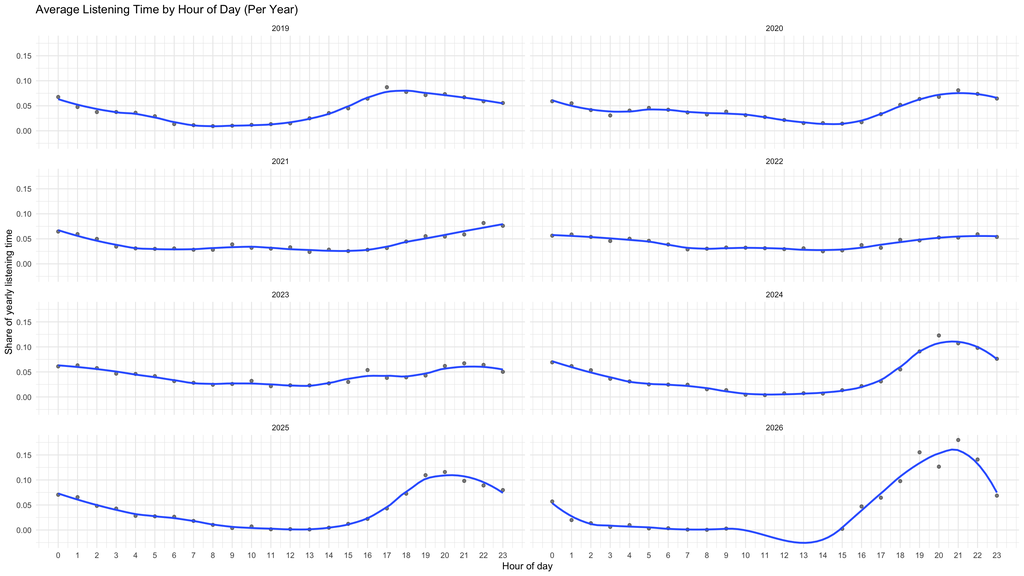

```r
ggplot(hourly_minutes_year,
       aes(x = hour, y = share_minutes)) +
  geom_point(alpha = 0.5) +
  geom_smooth(
    method = "loess",
    span = 0.4,
    se = FALSE
  ) +
  facet_wrap(~ year, ncol = 2) +
  scale_x_continuous(breaks = 0:23) +
  labs(
    title = "Average Listening Time by Hour of Day (Per Year)",
    x = "Hour of day",
    y = "Share of yearly listening time"
  ) +
  theme_minimal()
```

This is a typical listening day each year.

Intentional plays by artist and by song all time:

```r
# all-time intentional listens (clickrow) by ARTIST
clickrow_artist_alltime <- combined_data %>%
  filter(
    reason_start == "clickrow",
    !is.na(spotify_track_uri),
    !is.na(master_metadata_album_artist_name)
  ) %>%
  group_by(master_metadata_album_artist_name) %>%
  summarise(
    n_clickrow = n(),
    total_minutes_clickrow = sum(ms_played, na.rm = TRUE) / 60000,
    .groups = "drop"
  ) %>%
  arrange(desc(n_clickrow), desc(total_minutes_clickrow))

clickrow_artist_alltime
```

```
## # A tibble: 1,916 × 3
##    master_metadata_album_artist_name n_clickrow total_minutes_clickrow
##    <chr>                                  <int>                  <dbl>
##  1 Kid Cudi                                 789                  1446.
##  2 Lil Uzi Vert                             436                   925.
##  3 Jon Bellion                              414                   927.
##  4 Quinn XCII                               411                   906.
##  5 The Weeknd                               392                  1056.
##  6 The Chainsmokers                         348                   785.
##  7 Noah Kahan                               335                  1209.
##  8 Wiz Khalifa                              324                   828.
##  9 Bryce Vine                               319                   760.
## 10 Drake                                    292                   499.
## # ℹ 1,906 more rows
```

```r
# all-time intentional listens (clickrow) by SONG
clickrow_song_alltime <- combined_data %>%
  filter(
    reason_start == "clickrow",
    !is.na(spotify_track_uri),
    !is.na(master_metadata_track_name),
    !is.na(master_metadata_album_artist_name)
  ) %>%
  group_by(
    spotify_track_uri,
    master_metadata_track_name,
    master_metadata_album_artist_name
  ) %>%
  summarise(
    n_clickrow = n(),
    total_minutes_clickrow = sum(ms_played, na.rm = TRUE) / 60000,
    .groups = "drop"
  ) %>%
  arrange(desc(n_clickrow), desc(total_minutes_clickrow))

clickrow_song_alltime
```

```
## # A tibble: 5,359 × 5
##    spotify_track_uri    master_metadata_trac…¹ master_metadata_albu…² n_clickrow
##    <chr>                <chr>                  <chr>                       <int>
##  1 spotify:track:5Wr4u… Wounds                 Quinn XCII                     97
##  2 spotify:track:3XiNC… Sanguine Paradise      Lil Uzi Vert                   82
##  3 spotify:track:0qJGl… Heaven Knows           Five For Fighting              81
##  4 spotify:track:6pooR… Good Things Fall Apar… ILLENIUM                       69
##  5 spotify:track:3yn01… Call Your Mom          Noah Kahan                     65
##  6 spotify:track:3F18I… Welcome To Heartbreak  Kanye West                     63
##  7 spotify:track:25Q6X… Big Love (with EARTHG… Louis The Child                62
##  8 spotify:track:2Fjz5… Sing Me to Sleep       Alan Walker                    61
##  9 spotify:track:6pTDP… Maybe IDK              Jon Bellion                    61
## 10 spotify:track:3ZCTV… everything i wanted    Billie Eilish                  60
## # ℹ 5,349 more rows
## # ℹ abbreviated names: ¹master_metadata_track_name,
## #   ²master_metadata_album_artist_name
## # ℹ 1 more variable: total_minutes_clickrow <dbl>
```

Clickrows by artist:

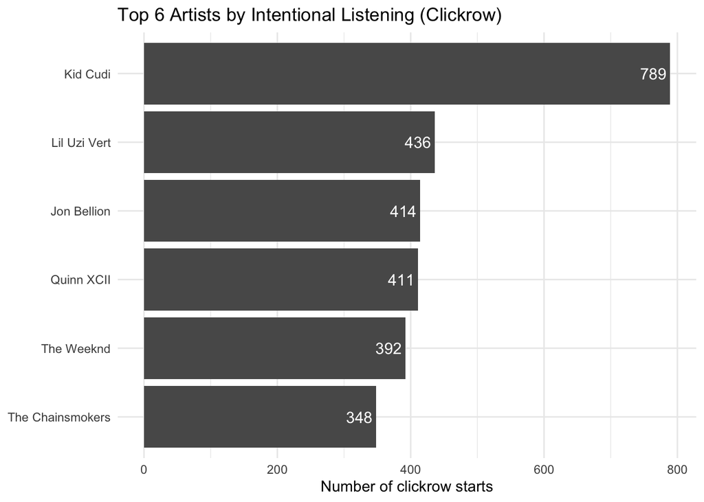

```r
top6_clickrow_artists <- clickrow_artist_alltime %>%
  slice_head(n = 6)

ggplot(
  top6_clickrow_artists,
  aes(
    x = reorder(master_metadata_album_artist_name, n_clickrow),
    y = n_clickrow
  )
) +
  geom_col() +
  geom_text(
    aes(label = n_clickrow),
    nudge_y = -25,
    color = "white",
    size = 4
  ) +
  coord_flip() +
  labs(
    title = "Top 6 Artists by Intentional Listening (Clickrow)",
    x = NULL,
    y = "Number of clickrow starts"
  ) +
  theme_minimal()
```

clickrow by song:

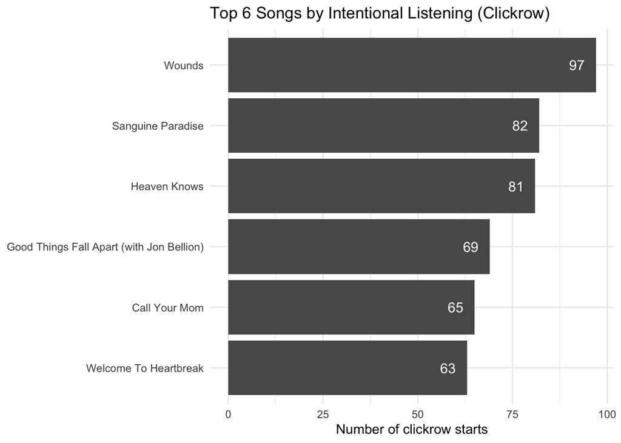

```r
top6_clickrow_songs <- clickrow_song_alltime %>%
  slice_head(n = 6)

ggplot(
  top6_clickrow_songs,
  aes(
    x = reorder(master_metadata_track_name, n_clickrow),
    y = n_clickrow
  )
) +
  geom_col() +
  geom_text(
    aes(label = n_clickrow),
    nudge_y = -5,
    color = "white",
    size = 4
  ) +
  coord_flip() +
  labs(
    title = "Top 6 Songs by Intentional Listening (Clickrow)",
    x = NULL,
    y = "Number of clickrow starts"
  ) +
  theme_minimal()
```

STREAKS:

```r
library(dplyr)
library(lubridate)

# monthly minutes (music only)
music_data <- combined_data %>%
  filter(
    !is.na(ts),
    !is.na(ms_played),
    !is.na(spotify_track_uri),
    !is.na(master_metadata_track_name),
    !is.na(master_metadata_album_artist_name)
  ) %>%
  mutate(month = floor_date(ts, "month"))

# ARTIST: top 3 each month + streaks (>= 2 consecutive months)
artist_monthly <- music_data %>%
  group_by(month, master_metadata_album_artist_name) %>%
  summarise(
    total_minutes = sum(ms_played, na.rm = TRUE) / 60000,
    .groups = "drop"
  )

artist_top3 <- artist_monthly %>%
  group_by(month) %>%
  arrange(desc(total_minutes), .by_group = TRUE) %>%
  slice_head(n = 3) %>%
  ungroup() %>%
  arrange(master_metadata_album_artist_name, month) %>%
  group_by(master_metadata_album_artist_name) %>%
  mutate(
    month_gap = as.integer(interval(lag(month), month) %/% months(1)),
    streak_id = cumsum(is.na(month_gap) | month_gap != 1)
  ) %>%
  group_by(master_metadata_album_artist_name, streak_id) %>%
  summarise(
    start_month = min(month),
    end_month = max(month),
    n_consecutive_months = n(),
    avg_top3_minutes = mean(total_minutes),
    .groups = "drop"
  ) %>%
  filter(n_consecutive_months >= 2) %>%
  arrange(desc(n_consecutive_months), desc(avg_top3_minutes))

artist_top3_streaks <- artist_top3

# SONG: top 3 each month + streaks (>= 2 consecutive months)
song_monthly <- music_data %>%
  group_by(month, spotify_track_uri, master_metadata_track_name, master_metadata_album_artist_name) %>%
  summarise(
    total_minutes = sum(ms_played, na.rm = TRUE) / 60000,
    .groups = "drop"
  )

song_top3 <- song_monthly %>%
  group_by(month) %>%
  arrange(desc(total_minutes), .by_group = TRUE) %>%
  slice_head(n = 3) %>%
  ungroup() %>%
  arrange(spotify_track_uri, month) %>%
  group_by(spotify_track_uri) %>%
  mutate(
    month_gap = as.integer(interval(lag(month), month) %/% months(1)),
    streak_id = cumsum(is.na(month_gap) | month_gap != 1)
  ) %>%
  group_by(spotify_track_uri, master_metadata_track_name, master_metadata_album_artist_name, streak_id) %>%
  summarise(
    start_month = min(month),
    end_month = max(month),
    n_consecutive_months = n(),
    avg_top3_minutes = mean(total_minutes),
    .groups = "drop"
  ) %>%
  filter(n_consecutive_months >= 2) %>%
  arrange(desc(n_consecutive_months), desc(avg_top3_minutes))

song_top3_streaks <- song_top3

artist_top3_streaks
```

```
## # A tibble: 39 × 6
##    master_metadata_album_art…¹ streak_id start_month         end_month
##    <chr>                           <int> <dttm>              <dttm>
##  1 Drake                               1 2019-01-01 00:00:00 2020-01-01 00:00:00
##  2 Noah Kahan                          3 2024-07-01 00:00:00 2024-12-01 00:00:00
##  3 Kid Cudi                            8 2021-10-01 00:00:00 2022-03-01 00:00:00
##  4 Kid Cudi                            6 2020-10-01 00:00:00 2021-02-01 00:00:00
##  5 Lil Uzi Vert                        5 2020-03-01 00:00:00 2020-06-01 00:00:00
##  6 Kid Cudi                           12 2023-11-01 00:00:00 2024-02-01 00:00:00
##  7 Noah Kahan                          6 2025-10-01 00:00:00 2026-01-01 00:00:00
##  8 The Weeknd                          1 2020-03-01 00:00:00 2020-05-01 00:00:00
##  9 Jon Bellion                         3 2025-04-01 00:00:00 2025-06-01 00:00:00
## 10 Quinn XCII                          1 2020-06-01 00:00:00 2020-08-01 00:00:00
## # ℹ 29 more rows
## # ℹ abbreviated name: ¹master_metadata_album_artist_name
## # ℹ 2 more variables: n_consecutive_months <int>, avg_top3_minutes <dbl>
```

```r
song_top3_streaks
```

```
## # A tibble: 18 × 8
##    spotify_track_uri     master_metadata_trac…¹ master_metadata_albu…² streak_id
##    <chr>                 <chr>                  <chr>                      <int>
##  1 spotify:track:3yn01P… Call Your Mom          Noah Kahan                     1
##  2 spotify:track:3XiNC9… Sanguine Paradise      Lil Uzi Vert                   1
##  3 spotify:track:2Fjz5Z… Sing Me to Sleep       Alan Walker                    1
##  4 spotify:track:5Wr4uj… Wounds                 Quinn XCII                     1
##  5 spotify:track:4bb94w… A Sweeter Place (feat… Selena Gomez                   1
##  6 spotify:track:3azJif… The Color Violet       Tory Lanez                     1
##  7 spotify:track:7BRD7x… CHIHIRO                Billie Eilish                  1
##  8 spotify:track:0qkdE1… What If I Never Get O… Lady A                         1
##  9 spotify:track:7qGoMO… Overthinker            INZO                           1
## 10 spotify:track:40yVW4… go away                Tate McRae                     1
## 11 spotify:track:59uQI0… Last Night             Morgan Wallen                  1
## 12 spotify:track:5EOF6D… GO ALL THE WAY         Quavo                          1
## 13 spotify:track:2WnAKZ… Anyone                 Justin Bieber                  1
## 14 spotify:track:3sTN90… Love$ick (feat. A$AP … Mura Masa                      1
## 15 spotify:track:0Gr2XQ… Arrival of the Birds   The Cinematic Orchest…         1
## 16 spotify:track:2aGc7d… Nowhere Man            Bryce Vine                     1
## 17 spotify:track:0prF3F… When I'm Gone          Wiz Khalifa                    1
## 18 spotify:track:2Fjz5Z… Sing Me to Sleep       Alan Walker                    2
## # ℹ abbreviated names: ¹master_metadata_track_name,
## #   ²master_metadata_album_artist_name
## # ℹ 4 more variables: start_month <dttm>, end_month <dttm>,
## #   n_consecutive_months <int>, avg_top3_minutes <dbl>
```

### #8

minutes played per year:

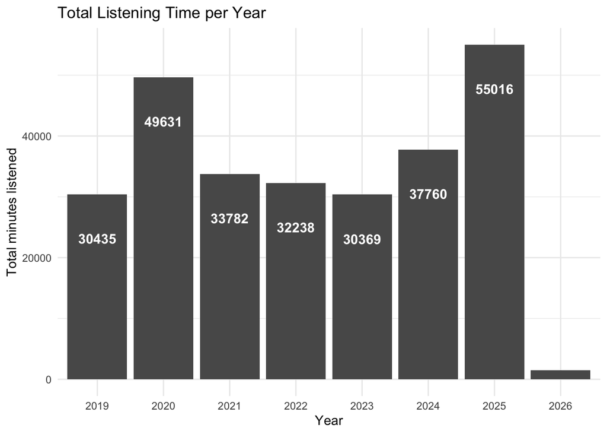

```r
library(ggplot2)

minutes_per_year <- combined_data %>%
  filter(
    !is.na(ts),
    !is.na(ms_played),
    !is.na(spotify_track_uri)
  ) %>%
  mutate(year = year(ts)) %>%
  group_by(year) %>%
  summarise(
    total_minutes = sum(ms_played, na.rm = TRUE) / 60000,
    .groups = "drop"
  ) %>%
  arrange(year)

ggplot(minutes_per_year,
       aes(x = factor(year), y = total_minutes)) +
  geom_col() +
  geom_text(
    aes(label = round(total_minutes)),
    vjust = 5,
    color = "white",
    size = 4,
    fontface = "bold"
  ) +
  labs(
    title = "Total Listening Time per Year",
    x = "Year",
    y = "Total minutes listened"
  ) +
  theme_minimal()
```

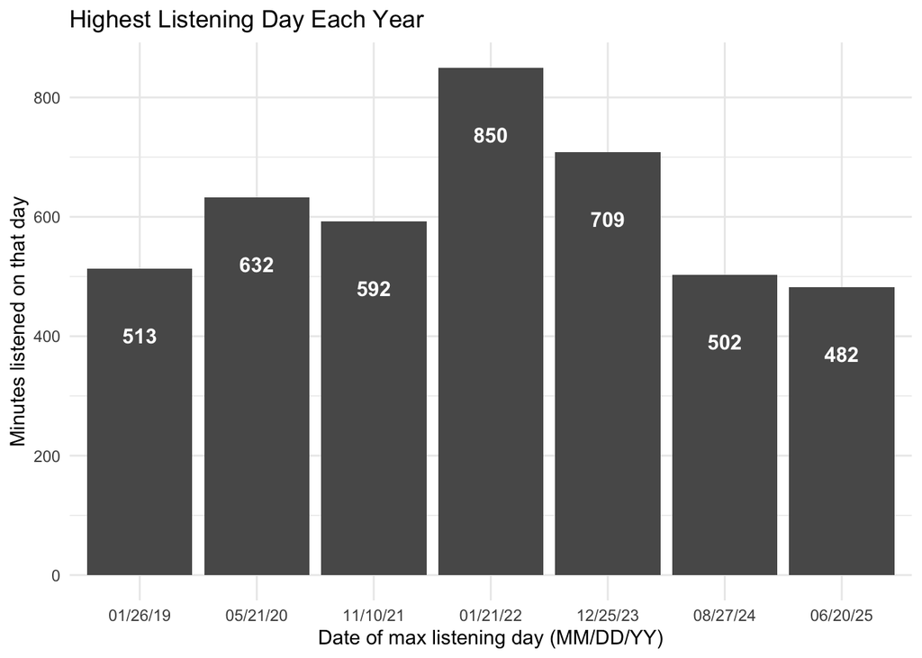

```r
# day with most listening minutes in each year
max_day_each_year <- combined_data %>%
  filter(
    !is.na(ts),
    !is.na(ms_played),
    !is.na(spotify_track_uri)
  ) %>%
  mutate(
    year = year(ts),
    date = as.Date(ts),
    minutes_played = ms_played / 60000
  ) %>%
  group_by(year, date) %>%
  summarise(
    total_minutes = sum(minutes_played, na.rm = TRUE),
    .groups = "drop"
  ) %>%
  filter(!is.na(year), year <= 2025) %>%
  group_by(year) %>%
  slice_max(total_minutes, n = 1, with_ties = FALSE) %>%
  ungroup() %>%
  arrange(year) %>%
  mutate(date_label = format(date, "%m/%d/%y"))

# x-axis labels: map each year -> its max-day date label
date_labels <- setNames(max_day_each_year$date_label, max_day_each_year$year)

ggplot(max_day_each_year, aes(x = factor(year), y = total_minutes)) +
  geom_col() +
  geom_text(
    aes(label = round(total_minutes)),
    vjust = 5,
    color = "white",
    size = 4,
    fontface = "bold"
  ) +
  scale_x_discrete(labels = date_labels) +
  labs(
    title = "Highest Listening Day Each Year",
    x = "Date of max listening day (MM/DD/YY)",
    y = "Minutes listened on that day"
  ) +
  theme_minimal()
```

still 8:

```r
unique_songs_year <- combined_data %>%
  filter(
    !is.na(ts),
    !is.na(spotify_track_uri)
  ) %>%
  mutate(year = year(ts)) %>%
  group_by(year) %>%
  summarise(
    n_unique_songs = n_distinct(spotify_track_uri),
    .groups = "drop"
  ) %>%
  filter(!is.na(year), year <= 2025) %>%
  arrange(year)

unique_songs_year
```

```
## # A tibble: 7 × 2
##    year n_unique_songs
##   <dbl>          <int>
## 1  2019           1970
## 2  2020           2511
## 3  2021           2221
## 4  2022           3333
## 5  2023           2725
## 6  2024           3797
## 7  2025           5538
```

```r
unique_songs_month <- combined_data %>%
  filter(
    !is.na(ts),
    !is.na(spotify_track_uri)
  ) %>%
  mutate(month = floor_date(ts, "month")) %>%
  group_by(month) %>%
  summarise(
    n_unique_songs = n_distinct(spotify_track_uri),
    .groups = "drop"
  ) %>%
  arrange(month)

unique_songs_month
```

```
## # A tibble: 85 × 2
##    month               n_unique_songs
##    <dttm>                       <int>
##  1 2019-01-01 00:00:00            802
##  2 2019-02-01 00:00:00            437
##  3 2019-03-01 00:00:00            489
##  4 2019-04-01 00:00:00            602
##  5 2019-05-01 00:00:00            518
##  6 2019-06-01 00:00:00            518
##  7 2019-07-01 00:00:00            552
##  8 2019-08-01 00:00:00            544
##  9 2019-09-01 00:00:00            692
## 10 2019-10-01 00:00:00            716
## # ℹ 75 more rows
```

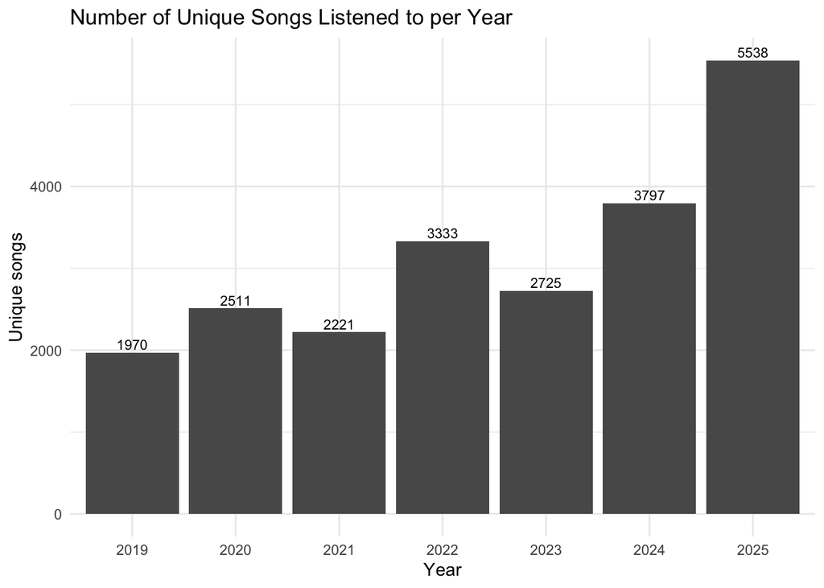

```r
ggplot(unique_songs_year,
       aes(x = factor(year), y = n_unique_songs)) +
  geom_col() +
  geom_text(
    aes(label = n_unique_songs),
    vjust = -0.3,
    size = 3
  ) +
  labs(
    title = "Number of Unique Songs Listened to per Year",
    x = "Year",
    y = "Unique songs"
  ) +
  theme_minimal()
```

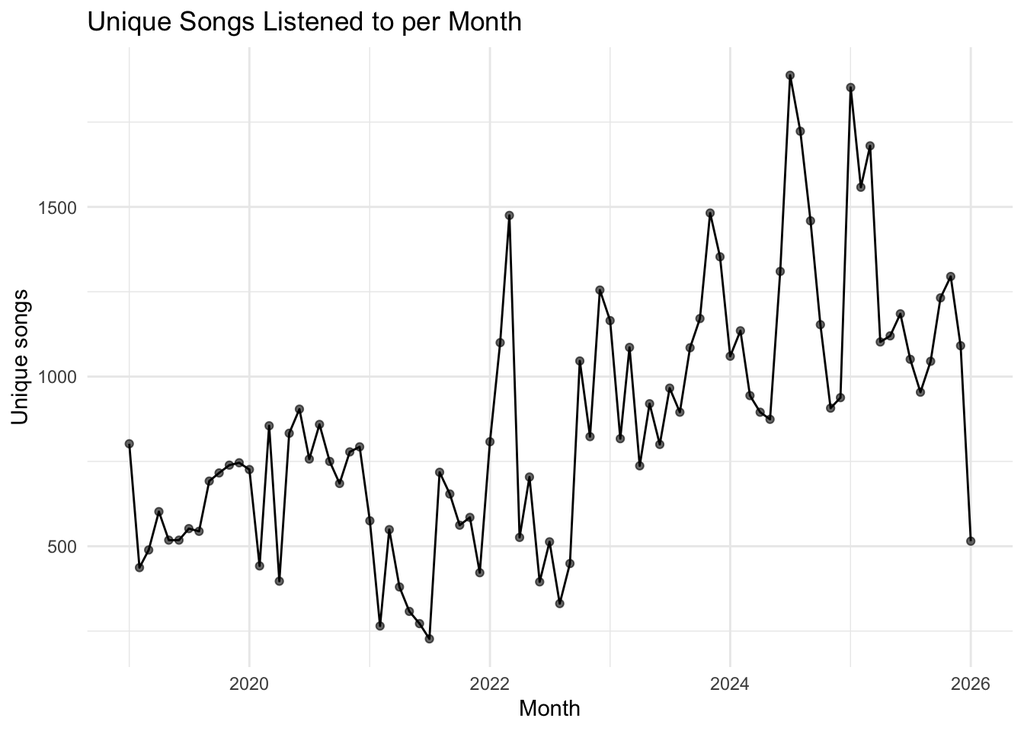

```r
ggplot(unique_songs_month,
       aes(x = month, y = n_unique_songs)) +
  geom_line() +
  geom_point(alpha = 0.6) +
  labs(
    title = "Unique Songs Listened to per Month",
    x = "Month",
    y = "Unique songs"
  ) +
  theme_minimal()
```

### #9

what songs are most commonly seen across multiple playlists?

Im thinking that this could show the versatility of that song and that in can be listened to in many different moods. So the songs that pop up the most in playlists are the most versatile.

I am thinking that if a person has enough playlists (p), and they have enough songs (s) in each playlist, then you could use this to make a tailored playlist of “comfort music” and in it are the n number of of songs in order of hgihest prevelance across all playlist– sayyyy the top 25-30 or so songs.

```r
library(dplyr)
library(tidyr)

playlist_items <- account_raw$Playlist1$playlists %>%
  tibble::as_tibble() %>%
  transmute(
    playlist_name = name,
    items
  ) %>%
  unnest_longer(items) %>%
  unnest(items)

song_playlist_counts <- playlist_items %>%
  filter(!is.na(track.trackUri)) %>%
  group_by(
    spotify_track_uri = track.trackUri,
    track_name = track.trackName,
    artist_name = track.artistName
  ) %>%
  summarise(
    n_playlists = n_distinct(playlist_name),
    .groups = "drop"
  ) %>%
  arrange(desc(n_playlists))

song_playlist_counts
```

```
## # A tibble: 857 × 4
##    spotify_track_uri                    track_name       artist_name n_playlists
##    <chr>                                <chr>            <chr>             <int>
##  1 spotify:track:3sTN90bIP2cJ1783ctHykO Love$ick (feat.… Mura Masa             8
##  2 spotify:track:3nAq2hCr1oWsIU54tS98pL Waves            Kanye West            7
##  3 spotify:track:3bBcJ5L26TPFKFhl2b0jrw Worst            Quinn XCII            6
##  4 spotify:track:0odHj0qIf86vHBsXB30IkZ So High (feat. … Wiz Khalifa           5
##  5 spotify:track:2WWfjbHALIb3e7FMcj9mr4 Line Of Sight    ODESZA                5
##  6 spotify:track:44CZRkOxv7UItaAUmh8PgN Doses & Mimosas  Cherub                5
##  7 spotify:track:4qWCFTuNnmGNdY4egtb4ZY Otherside        Post Malone           5
##  8 spotify:track:5EOF6DK6p9KycvqZwGcQzh GO ALL THE WAY   Quavo                 5
##  9 spotify:track:5mv1po6d9khHzWHp0C2yBs Balmain Jeans    Kid Cudi              5
## 10 spotify:track:6XkuklKiHYVTlVvWlTgQYP Erase Me - Main  Kid Cudi              5
## # ℹ 847 more rows
```

And now we can take 2 approaches here: we can randomly select songs, or we could do something like filter this list to all songs found in at least 5 playlists (or 3 or whatever you prefer) and then that playlist could be named “comfort songs”.

Also- if you wanted to do this but with artists— you could use that list to suggest songs in a playlist (kind of like the genius shuffle feature but for a playlist but it only shuffles the artists you tell it to).

### #10

times that two artists are played within the same 2 hour block of time:

```r
library(purrr)
library(lubridate)
library(tidyr)

# build 2-hour listening blocks (music only)
artist_blocks <- combined_data %>%
  filter(
    !is.na(master_metadata_album_artist_name),
    !is.na(ts),
    !is.na(spotify_track_uri)
  ) %>%
  mutate(
    block_start = floor_date(ts, unit = "2 hours")
  ) %>%
  distinct(block_start, master_metadata_album_artist_name)

# generate artist pairs within each block
artist_pairs <- artist_blocks %>%
  group_by(block_start) %>%
  summarise(
    artists = list(sort(unique(master_metadata_album_artist_name))),
    .groups = "drop"
  ) %>%
  filter(lengths(artists) >= 2) %>%
  mutate(pairs = purrr::map(artists, ~ combn(.x, 2, simplify = FALSE))) %>%
  select(pairs) %>%
  unnest(pairs) %>%
  transmute(
    artist_1 = map_chr(pairs, 1),
    artist_2 = map_chr(pairs, 2)
  )

# gount how often each artist pair appears together
top_artist_pairs <- artist_pairs %>%
  count(artist_1, artist_2, name = "n_shared_blocks") %>%
  arrange(desc(n_shared_blocks))

top_artist_pairs
```

```
## # A tibble: 312,860 × 3
##    artist_1     artist_2     n_shared_blocks
##    <chr>        <chr>                  <int>
##  1 Drake        Kid Cudi                1275
##  2 Drake        Lil Uzi Vert            1059
##  3 Drake        Quinn XCII              1044
##  4 Drake        Travis Scott            1011
##  5 Kid Cudi     Quinn XCII               978
##  6 Kid Cudi     Lil Uzi Vert             954
##  7 Kid Cudi     Travis Scott             889
##  8 Drake        Kanye West               880
##  9 Lil Uzi Vert Travis Scott             832
## 10 Lil Uzi Vert Quinn XCII               806
## # ℹ 312,850 more rows
```

IN-PROGRESS:

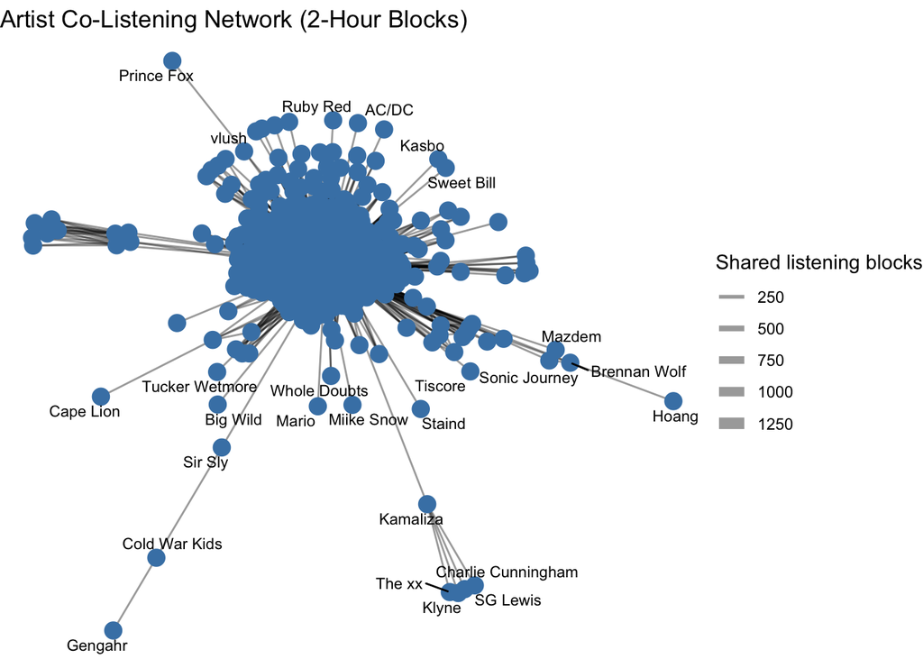

```r
library(dplyr)
library(igraph)
library(ggraph)

# keep only meaningful connections (cut noise)
artist_edges <- top_artist_pairs %>%
  filter(n_shared_blocks >= 10)   # adjust if needed

artist_graph <- graph_from_data_frame(
  artist_edges,
  directed = FALSE
)

ggraph(artist_graph, layout = "fr") +
  geom_edge_link(aes(width = n_shared_blocks), alpha = 0.4) +
  geom_node_point(size = 4, color = "steelblue") +
  geom_node_text(aes(label = name), repel = TRUE, size = 3) +
  scale_edge_width(range = c(0.5, 3)) +
  labs(
    title = "Artist Co-Listening Network (2-Hour Blocks)",
    edge_width = "Shared listening blocks"
  ) +
  theme_void()
```

will need to mess with this more because I need a 3D model. END OF THIS BETA VERSION

most common trios of artist found within the same 2 hour block:

```r
artist_trios <- artist_blocks %>%
  group_by(block_start) %>%
  summarise(
    artists = list(sort(unique(master_metadata_album_artist_name))),
    .groups = "drop"
  ) %>%
  filter(lengths(artists) >= 3, lengths(artists) <= 12) %>%
  mutate(
    trios = purrr::map(artists, ~ combn(.x, 3, simplify = FALSE))
  ) %>%
  select(trios) %>%
  tidyr::unnest(trios) %>%
  transmute(
    artist_1 = purrr::map_chr(trios, 1),
    artist_2 = purrr::map_chr(trios, 2),
    artist_3 = purrr::map_chr(trios, 3)
  ) %>%
  count(artist_1, artist_2, artist_3, name = "n_shared_blocks") %>%
  arrange(desc(n_shared_blocks))

artist_trios
```

```
## # A tibble: 171,743 × 4
##    artist_1     artist_2     artist_3     n_shared_blocks
##    <chr>        <chr>        <chr>                  <int>
##  1 Drake        Lil Uzi Vert Travis Scott              51
##  2 Drake        Kanye West   Kid Cudi                  48
##  3 Drake        Kanye West   Lil Uzi Vert              44
##  4 Drake        Kid Cudi     Travis Scott              44
##  5 Drake        Kid Cudi     Lil Uzi Vert              42
##  6 Drake        Kid Cudi     Quinn XCII                42
##  7 Drake        Kid Cudi     Lil Wayne                 40
##  8 Drake        Quinn XCII   Travis Scott              40
##  9 Kid Cudi     Lil Uzi Vert Travis Scott              39
## 10 Lil Uzi Vert Lil Wayne    Wiz Khalifa               39
## # ℹ 171,733 more rows
```

this is where at least one of the artist was clickrow (intentionally played), this eliminates the coincidence that they just happened to be played near each other and accounts for: maybe I was listening to an artist and it reminded me of another artist so I looked them up and clickrow started one of their tracks.

```r
library(dplyr)
library(lubridate)
library(tidyr)
library(purrr)

# 2-hour blocks/artist presence/whether that artist was clickrow within the block
artist_block_flags <- combined_data %>%
  filter(
    !is.na(ts),
    !is.na(spotify_track_uri),
    !is.na(master_metadata_album_artist_name)
  ) %>%
  mutate(block_start = floor_date(ts, "2 hours")) %>%
  group_by(block_start, master_metadata_album_artist_name) %>%
  summarise(
    artist_clickrow_in_block = any(reason_start == "clickrow", na.rm = TRUE),
    .groups = "drop"
  )

# build the pairs within each block -> keep only pairs where at least 1 artist is clickrow in that block
artist_pairs_clickrow1plus <- artist_block_flags %>%
  group_by(block_start) %>%
  summarise(
    artists = list(sort(unique(master_metadata_album_artist_name))),
    clickrow_artists = list(sort(unique(master_metadata_album_artist_name[artist_clickrow_in_block]))),
    .groups = "drop"
  ) %>%
  filter(lengths(artists) >= 2) %>%
  mutate(
    pairs = map(artists, ~ combn(.x, 2, simplify = FALSE))
  ) %>%
  select(block_start, pairs, clickrow_artists) %>%
  unnest(pairs) %>%
  transmute(
    block_start,
    artist_1 = map_chr(pairs, 1),
    artist_2 = map_chr(pairs, 2),
    keep_pair = (artist_1 %in% clickrow_artists) | (artist_2 %in% clickrow_artists)
  ) %>%
  filter(keep_pair) %>%
  count(artist_1, artist_2, name = "n_shared_blocks") %>%
  arrange(desc(n_shared_blocks))

artist_pairs_clickrow1plus
```

```
## # A tibble: 241,643 × 3
##    artist_1     artist_2     n_shared_blocks
##    <chr>        <chr>                  <int>
##  1 Drake        Kid Cudi                1275
##  2 Drake        Lil Uzi Vert            1059
##  3 Drake        Quinn XCII              1044
##  4 Drake        Travis Scott            1011
##  5 Kid Cudi     Quinn XCII               978
##  6 Kid Cudi     Lil Uzi Vert             954
##  7 Kid Cudi     Travis Scott             889
##  8 Drake        Kanye West               880
##  9 Lil Uzi Vert Travis Scott             832
## 10 Lil Uzi Vert Quinn XCII               806
## # ℹ 241,633 more rows
```

the counts do not look that different, in fact this looks identical to the list of artist PAIRS above that does not filter with clickrow like this does. However it is important to note that its in order of highest counts to lowest, so this just means that the “at least one is clickrow” already applied to our top ten before we even filtered for that.

You’ll notice that the overall number of rows has gone down significantly (about 70,000 less) so we did filter at least some pairs.

### #14

You have a group of friends getting together and you all have a fairly unique music taste.

take the most frequently listened to songs by each user (in this case just me). So lets do most listened to over the last week and then randomly select 7 songs from the top 25.

```r
library(dplyr)
library(lubridate)

set.seed(14)  # keep the "random 7" reproducible -> change if you want new picks

# most recent 7-day window in your data
latest_day <- as.Date(max(combined_data$ts, na.rm = TRUE))
start_day  <- latest_day - days(6)

# top 25 songs in that window (by total minutes), then random 7 from those 25
top25_last7days <- combined_data %>%
  filter(
    !is.na(ts),
    !is.na(ms_played),
    !is.na(spotify_track_uri),
    as.Date(ts) >= start_day,
    as.Date(ts) <= latest_day
  ) %>%
  group_by(
    spotify_track_uri,
    master_metadata_track_name,
    master_metadata_album_artist_name
  ) %>%
  summarise(
    total_minutes = sum(ms_played, na.rm = TRUE) / 60000,
    n_plays = n(),
    .groups = "drop"
  ) %>%
  arrange(desc(total_minutes), desc(n_plays)) %>%
  slice_head(n = 25)

random7_from_top25 <- top25_last7days %>%
  slice_sample(n = 7)

latest_day
```

```
## [1] "2026-01-13"
```

```r
start_day
```

```
## [1] "2026-01-07"
```

```r
top25_last7days
```

```
## # A tibble: 25 × 5
##    spotify_track_uri master_metadata_trac…¹ master_metadata_albu…² total_minutes
##    <chr>             <chr>                  <chr>                          <dbl>
##  1 spotify:track:1L… See The Light          Electric Guest                 67.4
##  2 spotify:track:1g… Without You            Chelsea Cutler                 19.6
##  3 spotify:track:1f… Off The Cuff           Glassio                        19.2
##  4 spotify:track:1g… Water Flow             Klyne                          15.2
##  5 spotify:track:4w… My Old Ways            Tame Impala                    13.4
##  6 spotify:track:0k… July                   Windser                        13.4
##  7 spotify:track:33… Sign                   VHS Collection                 12.2
##  8 spotify:track:0S… Always on the Run      Last Sun                       10.2
##  9 spotify:track:26… Deep Diving            Kid Cudi                        9.53
## 10 spotify:track:5Z… Lose Yourself          Eminem                          8.97
## # ℹ 15 more rows
## # ℹ abbreviated names: ¹master_metadata_track_name,
## #   ²master_metadata_album_artist_name
## # ℹ 1 more variable: n_plays <int>
```

```r
random7_from_top25
```

```
## # A tibble: 7 × 5
##   spotify_track_uri  master_metadata_trac…¹ master_metadata_albu…² total_minutes
##   <chr>              <chr>                  <chr>                          <dbl>
## 1 spotify:track:26Y… Deep Diving            Kid Cudi                        9.53
## 2 spotify:track:6rj… I Know                 Big Sean                        5.60
## 3 spotify:track:5KP… Heavier                ODESZA                          7.39
## 4 spotify:track:4n5… Minimum                Charlie Cunningham              6.50
## 5 spotify:track:1DW… Good News              Mac Miller                      5.70
## 6 spotify:track:5hU… Mirror                 Lil Wayne                       7.02
## 7 spotify:track:2Fj… Sing Me to Sleep       Alan Walker                     7.17
## # ℹ abbreviated names: ¹master_metadata_track_name,
## #   ²master_metadata_album_artist_name
## # ℹ 1 more variable: n_plays <int>
```

Now we have 7 songs that we know I will know and like. Now imagine having 6-7 friends do the exact same thing and we now have 42-49 songs to add to a playlist for when we all hang out or get together and want some music in the background.That is (ballpark) a 4 hour playlist which is perfect.

If you have less friends at the function- increase the number of randomly selected tracks from your top 25. if you have more, decrease the number of tracks selected from each person.

This would also be cool to be able to filter by mood of the song like how you already can in ‘likedsongs’ on spotify. Filters such as: “party” or “upbeat” or “chill” so that you can filter that playlist based on the mood of the setting.

This would require authorization from Spotipy or API to analyze beats and things like that so that i could filter but it is a cool idea. Would also need more songs for the filters to not filter to like 8 songs total.

### #15

If you hear a song and youre like “oh my god I used to listen to that all the time” but you can’t remember what songs you used to listen to around that time.

There could be a “time-period” button listed next to ‘add to queue’ on the drop down menu from the three dots in the top right corner of your phone in the Spotify app. And it will take you to a set list of time periods that you most frequently listen to that particular song and what other songs at the time were found near it in ms_played function.

```r
library(dplyr)
library(lubridate)
library(tidyr)
library(purrr)

# ordered listening rows with week + row_id
listening_ordered <- combined_data %>%
  filter(!is.na(ts),
         !is.na(spotify_track_uri),
         !is.na(master_metadata_track_name),
         !is.na(master_metadata_album_artist_name)) %>%
  arrange(ts) %>%
  mutate(
    row_id = row_number(),
    week = floor_date(ts, "week", week_start = 1)
  )

# rows where the track is Wounds by QuinnXCII (robust artist match)
wounds_rows <- listening_ordered %>%
  filter(
    tolower(master_metadata_track_name) == "wounds",
    grepl("quinn", master_metadata_album_artist_name, ignore.case = TRUE)
  ) %>%
  select(week, row_id, ts)

# weeks where Wounds appears >= 5 times
wounds_weeks <- wounds_rows %>%
  count(week, name = "n_wounds") %>%
  filter(n_wounds >= 5) %>%
  arrange(week)

wounds_weeks
```

```
##          week n_wounds
## 1  2020-06-15       53
## 2  2020-06-22       17
## 3  2020-06-29       11
## 4  2020-07-06        9
## 5  2020-07-13       13
## 6  2020-07-20       12
## 7  2020-07-27        7
## 8  2020-08-03        8
## 9  2020-08-10        5
## 10 2021-04-05        6
```

```r
# all songs within +/- 5 plays of EACH Wounds play, within the SAME week
wounds_around_all <- wounds_rows %>%
  semi_join(wounds_weeks, by = "week") %>%
  mutate(
    context_row_id = map(row_id, ~ (.x - 5):(.x + 5))
  ) %>%
  unnest(context_row_id) %>%
  left_join(
    listening_ordered %>%
      select(row_id, week, ts,
             spotify_track_uri,
             master_metadata_track_name,
             master_metadata_album_artist_name),
    by = c("context_row_id" = "row_id")
  ) %>%
  filter(
    !is.na(spotify_track_uri),
    week.y == week.x,                 # keep only plays in the same week
    context_row_id != row_id          # drop the Wounds play itself
  ) %>%
  transmute(
    week = week.x,
    wounds_ts = ts.x,                 # timestamp of the specific Wounds play
    context_ts = ts.y,                # timestamp of the surrounding play
    offset = context_row_id - row_id, # -5..-1, +1..+5
    spotify_track_uri,
    track_name = master_metadata_track_name,
    artist_name = master_metadata_album_artist_name
  ) %>%
  arrange(week, wounds_ts, offset)

wounds_around_all
```

```
## # A tibble: 1,385 × 7
##    week                wounds_ts           context_ts          offset
##    <dttm>              <dttm>              <dttm>               <int>
##  1 2020-06-15 00:00:00 2020-06-16 23:11:45 2020-06-16 22:53:16     -5
##  2 2020-06-15 00:00:00 2020-06-16 23:11:45 2020-06-16 22:53:17     -4
##  3 2020-06-15 00:00:00 2020-06-16 23:11:45 2020-06-16 22:53:18     -3
##  4 2020-06-15 00:00:00 2020-06-16 23:11:45 2020-06-16 22:58:35     -2
##  5 2020-06-15 00:00:00 2020-06-16 23:11:45 2020-06-16 23:03:53     -1
##  6 2020-06-15 00:00:00 2020-06-16 23:11:45 2020-06-16 23:15:44      1
##  7 2020-06-15 00:00:00 2020-06-16 23:11:45 2020-06-16 23:15:48      2
##  8 2020-06-15 00:00:00 2020-06-16 23:11:45 2020-06-16 23:19:01      3
##  9 2020-06-15 00:00:00 2020-06-16 23:11:45 2020-06-16 23:23:27      4
## 10 2020-06-15 00:00:00 2020-06-16 23:11:45 2020-06-16 23:27:10      5
## # ℹ 1,375 more rows
## # ℹ 3 more variables: spotify_track_uri <chr>, track_name <chr>,
## #   artist_name <chr>
```

gets rid of duplicates and returns how often that song was + or -5 from “Wounds”:

```r
week_pick <- as.Date("2020-07-13")  # <-- change this

wounds_week_songs <- wounds_around_all %>%
  filter(week == week_pick) %>%
  count(spotify_track_uri, track_name, artist_name, name = "n_around_wounds") %>%
  arrange(desc(n_around_wounds), track_name, artist_name)

wounds_week_songs
```

```
## # A tibble: 50 × 4
##    spotify_track_uri                    track_name   artist_name n_around_wounds
##    <chr>                                <chr>        <chr>                 <int>
##  1 spotify:track:44gRhRi2OhEf7moAUj6MD1 The Bigger … Lil Baby                 10
##  2 spotify:track:3nAq2hCr1oWsIU54tS98pL Waves        Kanye West                8
##  3 spotify:track:5Wr4ujVuTDx08xdQeNzbhL Wounds       Quinn XCII                6
##  4 spotify:track:5n8Y6tntsM1RQiDMCXOcB3 Giving Up G… Chelsea Cu…               5
##  5 spotify:track:14BH4qO7pgCmIe6mgLKOK3 Someone To … BANNERS                   5
##  6 spotify:track:0lNFKo6PVwAGnEdZfp9UfT Fake Denim   Quinn XCII                4
##  7 spotify:track:5lN1EH25gdiqT1SFALMAq1 Gold on the… The Black …               4
##  8 spotify:track:6dfXwa0dI1sBm4CIePuOYM Levels       Avicii                    4
##  9 spotify:track:4h5N4KyWZMtpeH9vhXSXjd Life's A Me… Juice WRLD                4
## 10 spotify:track:6ZGO8DVU5ZrpEAzNjTO0Kc Nobody Like… Louis The …               4
## # ℹ 40 more rows
```

so during the week of 2020-07-13 I most commonly listened The Bigger Picture by Lil Baby around the time i listened to “Wounds” by QuinnXCII. And now you have a playlist of song that take you back to that specific time period. If this doesn’t seem right to you or think that you were maybe thinking of songs during another “Wounds” by QuinnXCII binge then just go through the other weeks in the above list and they will return different lists of what you listened to that week around the song. Try a different week, maybe it was longer ago than you think or vice versa.